# INN_ReneWind_Main_Project_LowCode_Notebook

## Business Context

Renewable energy sources play an increasingly important role in the global energy mix, as the effort to reduce the environmental impact of energy production increases.

Out of all the renewable energy alternatives, wind energy is one of the most developed technologies worldwide. The U.S Department of Energy has put together a guide to achieving operational efficiency using predictive maintenance practices.

Predictive maintenance uses sensor information and analysis methods to measure and predict degradation and future component capability. The idea behind predictive maintenance is that failure patterns are predictable and if component failure can be predicted accurately and the component is replaced before it fails, the costs of operation and maintenance will be much lower.

The sensors fitted across different machines involved in the process of energy generation collect data related to various environmental factors (temperature, humidity, wind speed, etc.) and additional features related to various parts of the wind turbine (gearbox, tower, blades, break, etc.).

## Objective

“ReneWind” is a company working on improving the machinery/processes involved in the production of wind energy using machine learning and has collected data of generator failure of wind turbines using sensors. They have shared a ciphered version of the data, as the data collected through sensors is confidential (the type of data collected varies with companies). Data has 40 predictors, 20000 observations in the training set and 5000 in the test set.

The objective is to build various classification models, tune them, and find the best one that will help identify failures so that the generators could be repaired before failing/breaking to reduce the overall maintenance cost. The nature of predictions made by the classification model will translate as follows:

- True positives (TP) are failures correctly predicted by the model. These will result in repairing costs.
- False negatives (FN) are real failures where there is no detection by the model. These will result in replacement costs.
- False positives (FP) are detections where there is no failure. These will result in inspection costs.

It is given that the cost of repairing a generator is much less than the cost of replacing it, and the cost of inspection is less than the cost of repair.

“1” in the target variables should be considered as “failure” and “0” represents “No failure”.

# **Problem Statement**

## Data Description

The data provided is a transformed version of the original data which was collected using sensors.

- Train.csv - To be used for training and tuning of models.
- Test.csv - To be used only for testing the performance of the final best model.

Both the datasets consist of 40 predictor variables and 1 target variable.

# **Please read the instructions carefully before starting the project.**

This is a commented Jupyter IPython Notebook file in which all the instructions and tasks to be performed are mentioned.

- Blanks '_______' are provided in the notebook that needs to be filled with an appropriate code to get the correct result. With every '_______' blank, there is a comment that briefly describes what needs to be filled in the blank space.
- Identify the task to be performed correctly, and only then proceed to write the required code.
- Fill the code wherever asked by the commented lines like "# write your code here" or "# complete the code". Running incomplete code may throw error.
- Please run the codes in a sequential manner from the beginning to avoid any unnecessary errors.
- Add the results/observations (wherever mentioned) derived from the analysis in the presentation and submit the same.

# **Installing and Importing the necessary libraries**

```python
# Installing the libraries with the specified version
#!pip install --no-deps tensorflow==2.18.0 scikit-learn==1.3.2 matplotlib===3.8.3 seaborn==0.13.2 numpy==1.26.4 pandas==2.2.2 -q --user --no-warn-script-location
```

```python
#!pip install scikit-learn tensorflow seaborn
```

```python
import sys
!{sys.executable} -m pip install scikit-learn
```

[output not shown]

```python
import sklearn
print(sklearn.__version__)
```

```
1.8.0
```

```python
from sklearn.model_selection import train_test_split
import sklearn

print(sklearn.__version__)
```

```
1.8.0
```

```python
import sys
!{sys.executable} -m pip install seaborn tensorflow
```

[output not shown]

```python
import seaborn as sns
import tensorflow as tf

print("Seaborn OK")
print("TensorFlow version:", tf.__version__)
```

```
Seaborn OK
TensorFlow version: 2.21.0
```

**Note**:

- After running the above cell, kindly restart the runtime (for Google Colab) or notebook kernel (for Jupyter Notebook), and run all cells sequentially from the next cell.
- On executing the above line of code, you might see a warning regarding package dependencies. This error message can be ignored as the above code ensures that all necessary libraries and their dependencies are maintained to successfully execute the code in **this notebook**.

```python
# Library for data manipulation and analysis.
import pandas as pd
# Fundamental package for scientific computing.
import numpy as np
#splitting datasets into training and testing sets.
from sklearn.model_selection import train_test_split
#Imports tools for data preprocessing including label encoding, one-hot encoding, and standard scaling
from sklearn.preprocessing import LabelEncoder, OneHotEncoder,StandardScaler
#Imports a class for imputing missing values in datasets.
from sklearn.impute import SimpleImputer
#Imports the Matplotlib library for creating visualizations.
from sklearn.metrics import confusion_matrix
import matplotlib.pyplot as plt
# Imports the Seaborn library for statistical data visualization.
import seaborn as sns
# Time related functions.
import time
#Imports functions for evaluating the performance of machine learning models
from sklearn.metrics import confusion_matrix, f1_score,accuracy_score, recall_score, precision_score, classification_report
#Imports metrics from
from sklearn import metrics

#Imports the tensorflow,keras and layers.
import tensorflow
import tensorflow as tf
from tensorflow.keras.models import Sequential
from tensorflow.keras.layers import Dense
from tensorflow.keras.layers import Dense, Input, Dropout,BatchNormalization
from tensorflow.keras import backend

# to suppress unnecessary warnings
import warnings
warnings.filterwarnings("ignore")
```

# **Loading the Data**

```python
# uncomment and run the following lines for Google Colab
# from google.colab import drive
# drive.mount('/content/drive')
```

```python
df = pd.read_csv("Train.csv")    # Complete the code to import the training data
df_test = pd.read_csv("Test.csv")    # Complete the code to import the test data
```

# **Data Overview**

The initial steps to get an overview of any dataset is to:

- observe the first few rows of the dataset, to check whether the dataset has been loaded properly or not
- get information about the number of rows and columns in the dataset
- find out the data types of the columns to ensure that data is stored in the preferred format and the value of each property is as expected.
- check the statistical summary of the dataset to get an overview of the numerical columns of the data

## Checking the shape of the dataset

```python
# Checking the number of rows and columns in the training data
df.shape # Complete the code to print the shape of the train data
```

```
(20000, 41)
```

```python
# Checking the number of rows and columns in the test data
df_test.shape # Complete the code to print the shape of the test data
```

```
(5000, 41)
```

```python
# let's create a copy of the training data
data = df.copy()
```

```python
# let's create a copy of the testing  data
data_test = df_test.copy()
```

### Observations

- The training dataset contains **20,000 rows** and **41 columns**.
- The test dataset contains **5,000 rows** and **41 columns**.
- Since both datasets have the same number of columns, the structure of the training and test data is consistent.
- The dataset contains **40 predictor variables** and **1 target variable**, which matches the project description.
- Copies of both datasets were created (`data` and `data_test`) to preserve the original datasets and avoid accidental modification during preprocessing and analysis.

## Displaying the first few rows of the dataset

```python
# let's view the first 5 rows of the data
data.head() # Complete the code to view the first five rows of the train data
```

|  | V1 | V2 | V3 | V4 | V5 | V6 | V7 | V8 | V9 | V10 | ... | V32 | V33 | V34 | V35 | V36 | V37 | V38 | V39 | V40 | Target |
| --- | --- | --- | --- | --- | --- | --- | --- | --- | --- | --- | --- | --- | --- | --- | --- | --- | --- | --- | --- | --- | --- |
| 0 | -4.464606 | -4.679129 | 3.101546 | 0.506130 | -0.221083 | -2.032511 | -2.910870 | 0.050714 | -1.522351 | 3.761892 | ... | 3.059700 | -1.690440 | 2.846296 | 2.235198 | 6.667486 | 0.443809 | -2.369169 | 2.950578 | -3.480324 | 0 |
| 1 | 3.365912 | 3.653381 | 0.909671 | -1.367528 | 0.332016 | 2.358938 | 0.732600 | -4.332135 | 0.565695 | -0.101080 | ... | -1.795474 | 3.032780 | -2.467514 | 1.894599 | -2.297780 | -1.731048 | 5.908837 | -0.386345 | 0.616242 | 0 |
| 2 | -3.831843 | -5.824444 | 0.634031 | -2.418815 | -1.773827 | 1.016824 | -2.098941 | -3.173204 | -2.081860 | 5.392621 | ... | -0.257101 | 0.803550 | 4.086219 | 2.292138 | 5.360850 | 0.351993 | 2.940021 | 3.839160 | -4.309402 | 0 |
| 3 | 1.618098 | 1.888342 | 7.046143 | -1.147285 | 0.083080 | -1.529780 | 0.207309 | -2.493629 | 0.344926 | 2.118578 | ... | -3.584425 | -2.577474 | 1.363769 | 0.622714 | 5.550100 | -1.526796 | 0.138853 | 3.101430 | -1.277378 | 0 |
| 4 | -0.111440 | 3.872488 | -3.758361 | -2.982897 | 3.792714 | 0.544960 | 0.205433 | 4.848994 | -1.854920 | -6.220023 | ... | 8.265896 | 6.629213 | -10.068689 | 1.222987 | -3.229763 | 1.686909 | -2.163896 | -3.644622 | 6.510338 | 0 |

5 rows × 41 columns

```python
#viewing first 5 rows of the test data
data_test.head() # Complete the code to view the first five rows of the test data
```

|  | V1 | V2 | V3 | V4 | V5 | V6 | V7 | V8 | V9 | V10 | ... | V32 | V33 | V34 | V35 | V36 | V37 | V38 | V39 | V40 | Target |
| --- | --- | --- | --- | --- | --- | --- | --- | --- | --- | --- | --- | --- | --- | --- | --- | --- | --- | --- | --- | --- | --- |
| 0 | -0.613489 | -3.819640 | 2.202302 | 1.300420 | -1.184929 | -4.495964 | -1.835817 | 4.722989 | 1.206140 | -0.341909 | ... | 2.291204 | -5.411388 | 0.870073 | 0.574479 | 4.157191 | 1.428093 | -10.511342 | 0.454664 | -1.448363 | 0 |
| 1 | 0.389608 | -0.512341 | 0.527053 | -2.576776 | -1.016766 | 2.235112 | -0.441301 | -4.405744 | -0.332869 | 1.966794 | ... | -2.474936 | 2.493582 | 0.315165 | 2.059288 | 0.683859 | -0.485452 | 5.128350 | 1.720744 | -1.488235 | 0 |
| 2 | -0.874861 | -0.640632 | 4.084202 | -1.590454 | 0.525855 | -1.957592 | -0.695367 | 1.347309 | -1.732348 | 0.466500 | ... | -1.318888 | -2.997464 | 0.459664 | 0.619774 | 5.631504 | 1.323512 | -1.752154 | 1.808302 | 1.675748 | 0 |
| 3 | 0.238384 | 1.458607 | 4.014528 | 2.534478 | 1.196987 | -3.117330 | -0.924035 | 0.269493 | 1.322436 | 0.702345 | ... | 3.517918 | -3.074085 | -0.284220 | 0.954576 | 3.029331 | -1.367198 | -3.412140 | 0.906000 | -2.450889 | 0 |
| 4 | 5.828225 | 2.768260 | -1.234530 | 2.809264 | -1.641648 | -1.406698 | 0.568643 | 0.965043 | 1.918379 | -2.774855 | ... | 1.773841 | -1.501573 | -2.226702 | 4.776830 | -6.559698 | -0.805551 | -0.276007 | -3.858207 | -0.537694 | 0 |

5 rows × 41 columns

## Checking the data types of the columns in the dataset

```python
# let's check the data types of the columns in the dataset
data.dtypes # Complete the code to view the data types of the columns in the train data
```

```
V1        float64
V2        float64
V3        float64
V4        float64
V5        float64
V6        float64
V7        float64
V8        float64
V9        float64
V10       float64
V11       float64
V12       float64
V13       float64
V14       float64
V15       float64
V16       float64
V17       float64
V18       float64
V19       float64
V20       float64
V21       float64
V22       float64
V23       float64
V24       float64
V25       float64
V26       float64
V27       float64
V28       float64
V29       float64
V30       float64
V31       float64
V32       float64
V33       float64
V34       float64
V35       float64
V36       float64
V37       float64
V38       float64
V39       float64
V40       float64
Target      int64
dtype: object
```

- Converting Target column to float

```python
data['Target'] = data['Target'].astype(float)
```

Now checking for test data

```python
data_test.dtypes # Complete the code to view the data types of the columns in the test data
```

```
V1        float64
V2        float64
V3        float64
V4        float64
V5        float64
V6        float64
V7        float64
V8        float64
V9        float64
V10       float64
V11       float64
V12       float64
V13       float64
V14       float64
V15       float64
V16       float64
V17       float64
V18       float64
V19       float64
V20       float64
V21       float64
V22       float64
V23       float64
V24       float64
V25       float64
V26       float64
V27       float64
V28       float64
V29       float64
V30       float64
V31       float64
V32       float64
V33       float64
V34       float64
V35       float64
V36       float64
V37       float64
V38       float64
V39       float64
V40       float64
Target      int64
dtype: object
```

Converting Target to float

```python
data_test['Target'] = data_test['Target'].astype(float)
```

## Checking for duplicate values

```python
# let's check for duplicate values in the data
data.duplicated().sum() # Complete the code to check for duplicate values in the train data
```

```
np.int64(0)
```

## Checking for missing values

```python
# let's check for missing values in the data
data.isnull().sum()
```

```
V1        18
V2        18
V3         0
V4         0
V5         0
V6         0
V7         0
V8         0
V9         0
V10        0
V11        0
V12        0
V13        0
V14        0
V15        0
V16        0
V17        0
V18        0
V19        0
V20        0
V21        0
V22        0
V23        0
V24        0
V25        0
V26        0
V27        0
V28        0
V29        0
V30        0
V31        0
V32        0
V33        0
V34        0
V35        0
V36        0
V37        0
V38        0
V39        0
V40        0
Target     0
dtype: int64
```

```python
# let's check for missing values in the test data
data_test.isnull().sum() #
```

```
V1        5
V2        6
V3        0
V4        0
V5        0
V6        0
V7        0
V8        0
V9        0
V10       0
V11       0
V12       0
V13       0
V14       0
V15       0
V16       0
V17       0
V18       0
V19       0
V20       0
V21       0
V22       0
V23       0
V24       0
V25       0
V26       0
V27       0
V28       0
V29       0
V30       0
V31       0
V32       0
V33       0
V34       0
V35       0
V36       0
V37       0
V38       0
V39       0
V40       0
Target    0
dtype: int64
```

## Statistical summary of the dataset

```python
# let's view the statistical summary of the numerical columns in the data
data.describe() # Complete the code to view the statistical summary of the train data
```

|  | V1 | V2 | V3 | V4 | V5 | V6 | V7 | V8 | V9 | V10 | ... | V32 | V33 | V34 | V35 | V36 | V37 | V38 | V39 | V40 | Target |
| --- | --- | --- | --- | --- | --- | --- | --- | --- | --- | --- | --- | --- | --- | --- | --- | --- | --- | --- | --- | --- | --- |
| count | 19982.000000 | 19982.000000 | 20000.000000 | 20000.000000 | 20000.000000 | 20000.000000 | 20000.000000 | 20000.000000 | 20000.000000 | 20000.000000 | ... | 20000.000000 | 20000.000000 | 20000.000000 | 20000.000000 | 20000.000000 | 20000.000000 | 20000.000000 | 20000.000000 | 20000.000000 | 20000.000000 |
| mean | -0.271996 | 0.440430 | 2.484699 | -0.083152 | -0.053752 | -0.995443 | -0.879325 | -0.548195 | -0.016808 | -0.012998 | ... | 0.303799 | 0.049825 | -0.462702 | 2.229620 | 1.514809 | 0.011316 | -0.344025 | 0.890653 | -0.875630 | 0.055500 |
| std | 3.441625 | 3.150784 | 3.388963 | 3.431595 | 2.104801 | 2.040970 | 1.761626 | 3.295756 | 2.160568 | 2.193201 | ... | 5.500400 | 3.575285 | 3.183841 | 2.937102 | 3.800860 | 1.788165 | 3.948147 | 1.753054 | 3.012155 | 0.228959 |
| min | -11.876451 | -12.319951 | -10.708139 | -15.082052 | -8.603361 | -10.227147 | -7.949681 | -15.657561 | -8.596313 | -9.853957 | ... | -19.876502 | -16.898353 | -17.985094 | -15.349803 | -14.833178 | -5.478350 | -17.375002 | -6.438880 | -11.023935 | 0.000000 |
| 25% | -2.737146 | -1.640674 | 0.206860 | -2.347660 | -1.535607 | -2.347238 | -2.030926 | -2.642665 | -1.494973 | -1.411212 | ... | -3.420469 | -2.242857 | -2.136984 | 0.336191 | -0.943809 | -1.255819 | -2.987638 | -0.272250 | -2.940193 | 0.000000 |
| 50% | -0.747917 | 0.471536 | 2.255786 | -0.135241 | -0.101952 | -1.000515 | -0.917179 | -0.389085 | -0.067597 | 0.100973 | ... | 0.052073 | -0.066249 | -0.255008 | 2.098633 | 1.566526 | -0.128435 | -0.316849 | 0.919261 | -0.920806 | 0.000000 |
| 75% | 1.840112 | 2.543967 | 4.566165 | 2.130615 | 1.340480 | 0.380330 | 0.223695 | 1.722965 | 1.409203 | 1.477045 | ... | 3.761722 | 2.255134 | 1.436935 | 4.064358 | 3.983939 | 1.175533 | 2.279399 | 2.057540 | 1.119897 | 0.000000 |
| max | 15.493002 | 13.089269 | 17.090919 | 13.236381 | 8.133797 | 6.975847 | 8.006091 | 11.679495 | 8.137580 | 8.108472 | ... | 23.633187 | 16.692486 | 14.358213 | 15.291065 | 19.329576 | 7.467006 | 15.289923 | 7.759877 | 10.654265 | 1.000000 |

8 rows × 41 columns

## Data Overview and Initial Findings

### Missing Value Analysis

The missing value analysis shows that:

- Only two variables, **V1** and **V2**, contain missing values.
- Both variables have **18 missing observations** each.
- All remaining predictor variables and the target variable contain no missing values.
- Since the dataset contains 20,000 observations, the percentage of missing values is extremely small.

### Importance of Missing Value Analysis

Checking for missing values is important because:

- Missing values can negatively impact model performance and may cause errors during training.
- Many machine learning algorithms cannot process null values directly.
- Proper treatment of missing values improves model reliability and prediction accuracy.
- Since the number of missing values is very low, simple imputation techniques such as mean or median imputation can be applied effectively without significantly changing the data distribution.

## Statistical Summary Observations

The statistical summary provides important insights into the numerical variables in the dataset.

Key observations include:

- The dataset contains **40 predictor variables** and **1 target variable**.
- Several variables have relatively large standard deviations, indicating high variability in sensor readings.
- The wide gap between minimum and maximum values suggests the possible presence of outliers in multiple features.
- The target variable has a mean value of approximately **0.0555**, indicating that only about **5.5%** of observations correspond to generator failures.

### Importance of Statistical Summary

The statistical summary is important because:

- It helps understand the distribution and spread of the variables.
- It helps identify potential outliers that may affect model performance.
- It provides insight into whether scaling or normalization may be required before modeling.
- The low proportion of failure cases indicates that the dataset is **highly imbalanced**.

### Business and Modeling Implications

Class imbalance is critical in this project because:

- A model trained on imbalanced data may become biased toward predicting the majority class (“No Failure”).
- This can result in poor detection of actual failures.
- False Negatives are especially costly because undetected failures can lead to expensive generator replacement and operational downtime.
- Therefore, the final model should prioritize identifying failures effectively by improving Recall and reducing False Negatives, even if it results in slightly higher inspection costs from False Positives.
- Because of this imbalance, evaluation metrics such as **Recall, Precision, F1-score, and Confusion Matrix** are more meaningful than accuracy alone.

# **Exploratory Data Analysis**

## Univariate analysis

```python
# function to plot a boxplot and a histogram along the same scale.


def histogram_boxplot(data, feature, figsize=(12, 7), kde=False, bins=None):
    """
    Boxplot and histogram combined

    data: dataframe
    feature: dataframe column
    figsize: size of figure (default (12,7))
    kde: whether to the show density curve (default False)
    bins: number of bins for histogram (default None)
    """
    f2, (ax_box2, ax_hist2) = plt.subplots(
        nrows=2,  # Number of rows of the subplot grid= 2
        sharex=True,  # x-axis will be shared among all subplots
        gridspec_kw={"height_ratios": (0.25, 0.75)},
        figsize=figsize,
    )  # creating the 2 subplots
    sns.boxplot(
       data=data, x=feature, ax=ax_box2, showmeans=True, color="violet"
    )  # boxplot will be created and a star will indicate the mean value of the column
    sns.histplot(
        data=data, x=feature, kde=kde, ax=ax_hist2, bins=bins, palette="winter"
    ) if bins else sns.histplot(
        data=data, x=feature, kde=kde, ax=ax_hist2
    )  # For histogram
    ax_hist2.axvline(
        data[feature].mean(), color="green", linestyle="--"
    )  # Add mean to the histogram
    ax_hist2.axvline(
        data[feature].median(), color="black", linestyle="-"
    )  # Add median to the histogram
```

# Exploratory Data Analysis (EDA) – Univariate Analysis and Business Interpretation

## Overview

Univariate analysis was conducted on all numerical variables (V1–V40) and the target variable to better understand:

- the distribution of each feature,
- variability in sensor behavior,
- the presence of outliers,
- skewness,
- and potential preprocessing requirements before machine learning modeling.

Histograms and boxplots were used to evaluate the distribution and spread of each variable individually.

# Dataset Characteristics

The dataset contains:

### Training Dataset

- 20,000 observations
- 40 numerical predictor variables
- 1 binary target variable

### Testing Dataset

- 5,000 observations
- 40 numerical predictor variables
- 1 binary target variable

The target variable is:

- **0 = No Failure**
- **1 = Failure**

# Missing Value Analysis

## Observations

- Only variables **V1** and **V2** contain missing values.
- Both variables contain only **18 missing observations** each.
- All remaining variables and the target variable contain no missing values.

The percentage of missing values is extremely small relative to the overall dataset size.

## Why Missing Value Analysis Is Important

Checking for missing values is important because:

- Many machine learning algorithms cannot process null values directly.
- Missing data can negatively impact prediction accuracy and model stability.
- Improper handling of missing values may introduce bias into the model.

Since missingness is minimal, simple imputation methods such as:

- mean imputation,
- median imputation,
- or SimpleImputer

can effectively handle the issue without significantly altering the data distribution.

## Business Impact of Missing Values

Proper treatment of missing sensor readings helps:

- improve prediction reliability,
- reduce operational risk,
- and support more accurate maintenance decisions.

Ignoring missing values could increase the likelihood of inaccurate predictions and unexpected turbine failures.

# Univariate Analysis – Variables V1 to V21

## Observations

- Most variables from **V1 to V21** follow approximately:
  - bell-shaped,
  - normal,
  - or near-normal distributions.
- Several variables display:
  - slight positive skewness,
  - slight negative skewness,
  - and moderate asymmetry.
- Many variables contain visible outliers on both lower and upper ends of the distributions.
- The mean and median are relatively close for many variables, indicating moderate symmetry and stable sensor behavior.
- Variables such as:
  - **V3**
  - **V12**
  - **V13**
  - **V16**
  - **V21**

show:

- wider spreads,
- heavier tails,
- and higher variability.
- Histograms indicate that most variables are continuous numerical features with varying scales and ranges.
- Outliers are common across many variables, which is expected in real-world industrial sensor data.

# Why This Is Important for EDA

Performing univariate analysis is important because it helps:

- understand the behavior of each feature individually,
- identify skewness and unusual patterns,
- detect extreme values and operational anomalies,
- and determine whether preprocessing is required.

This analysis helps determine whether:

- scaling,
- normalization,
- transformation,
- or robust preprocessing techniques

may improve machine learning performance.

Since neural networks are sensitive to feature scale and distribution, understanding variable behavior is critical before model development.

# Business Interpretation – Variables V1 to V21

From a business perspective:

- Extreme sensor readings may indicate:
  - abnormal turbine behavior,
  - overheating,
  - vibration abnormalities,
  - mechanical stress,
  - or early signs of equipment degradation.
- Variables with high variability and frequent outliers may contain strong predictive signals for turbine failure.
- Detecting abnormal operating conditions early can help:
  - reduce downtime,
  - lower replacement costs,
  - improve turbine reliability,
  - and optimize maintenance planning.

# Additional Univariate Analysis – Variables V20 to V39

## Observations

Variables from **V20 to V39** also display distributions that are mostly:

- approximately normal,
- bell-shaped,
- or near-symmetric.

Several variables exhibit moderate skewness, particularly:

- **V21**
- **V24**
- **V26**
- **V27**
- **V31**
- **V32**
- **V36**

These variables show:

- longer tails,
- asymmetric distributions,
- and larger variability.

Additional observations include:

- Many variables contain substantial outliers on both sides of the distribution.
- Variables such as **V32** and **V36** display especially wide ranges and heavier tails.
- Some variables are tightly concentrated around the center, while others are more dispersed.
- Mean and median lines remain relatively close for several variables despite the presence of outliers.
- Mild positive skewness is observed in some variables where right tails extend further than left tails.

# Why This Is Important for EDA

Analyzing these variables is important because:

- it helps identify whether the data satisfies assumptions commonly used in machine learning and statistical modeling,
- highly skewed variables may require preprocessing,
- extreme outliers may strongly influence model performance,
- and wider distributions may indicate abnormal operational conditions.

Variables with heavy tails and large spreads may contain useful information related to:

- turbine instability,
- mechanical stress,
- and generator failure behavior.

This analysis also helps determine whether:

- feature engineering,
- dimensionality reduction,
- or advanced preprocessing

may improve model performance later in the project.

# Business Interpretation – Variables V20 to V39

From a business and operational perspective:

- Extreme sensor readings may represent:
  - overheating,
  - vibration irregularities,
  - unstable operating conditions,
  - or early component degradation.
- Variables with larger variability and extreme outliers may be particularly useful for predicting turbine failure events.
- Detecting unusual sensor behavior early can help:
  - reduce costly unplanned downtime,
  - improve maintenance scheduling,
  - and support predictive maintenance strategies.

Because turbine failures are rare but expensive, identifying subtle abnormal patterns in these variables may significantly improve maintenance decision-making.

# Variable V40 Analysis

## Observations

Variable **V40** follows an approximately bell-shaped distribution similar to many earlier sensor variables.

Additional observations include:

# Importance of Variable Distribution Analysis

Analyzing variable distributions helps identify:

- skewness,
- variability,
- outliers,
- and potential data quality concerns.

These insights help determine:

- whether scaling is required,
- whether transformations may improve model performance,
- and which variables may contribute strongly to predictive accuracy.

# Business Impact of Sensor Distribution Analysis

Stable sensor behavior improves the model’s ability to distinguish between:

- healthy turbine operation,
- and abnormal operating conditions.

Variables showing unusual or extreme behavior may act as early warning indicators for turbine failure and predictive maintenance systems.

# Target Variable Analysis

## Observations

The target variable shows a highly imbalanced distribution.

- Most observations belong to class **0 (No Failure)**.
- Only a small proportion belong to class **1 (Failure)**.

This confirms:

- approximately **94.5% No Failure**
- approximately **5.5% Failure**

The boxplot also highlights the strong imbalance between the two classes.

# Why Target Distribution Is Important

## 1. Class Imbalance Impacts Model Training

Machine learning models may become biased toward the majority class.

For example:

- A model predicting only "No Failure" could still achieve high accuracy.
- However, it would fail to identify actual turbine failures.

## 2. Accuracy Alone Becomes Misleading

Because failures are rare:

- Accuracy alone is not a reliable evaluation metric.

More meaningful metrics include:

- Recall,
- Precision,
- F1-score,
- ROC-AUC,
- and confusion matrix analysis.

## 3. Failure Detection Is the Main Business Objective

The business problem prioritizes early failure detection.

Missing a true failure (False Negative) may result in:

- turbine breakdown,
- expensive generator replacement,
- operational downtime,
- and increased maintenance expenses.

Therefore, the final model should prioritize:

- maximizing Recall,
- minimizing False Negatives,
- and improving failure detection performance.

# Overall EDA Findings

Combining the analysis from all variables:

## Key Findings

- Most variables follow approximately normal or near-normal distributions.
- Outliers are consistently present across nearly all variables.
- Several variables exhibit moderate skewness and heavy tails.
- Variability differs substantially across sensor variables.
- No strong multimodal distributions are observed.
- The dataset appears numerically stable overall after preprocessing.

Variables such as:

- V16,
- V21,
- V24,
- V31,
- V32,
- and V36

show especially high variability and extreme values, making them potentially important predictors of turbine failure.

# Overall Importance of EDA

Exploratory Data Analysis is essential because it helps:

- understand data quality,
- identify missing values,
- detect abnormal patterns,
- analyze feature distributions,
- recognize class imbalance,
- and guide preprocessing and modeling decisions.

EDA ensures:

- appropriate preprocessing strategies,
- reliable machine learning inputs,
- and alignment between technical modeling and business objectives.

# Overall Business Interpretation

The EDA findings suggest that:

- Sensor readings contain meaningful operational patterns.
- Abnormal sensor behavior may act as early warning signals for failure.
- Certain variables may provide strong predictive signals for generator breakdown.
- The dataset is suitable for predictive maintenance modeling.

The strong class imbalance indicates that:

- failure prediction is challenging,
- but critically important from a business perspective.

# Overall Business Impact

A successful predictive maintenance model can help ReneWind:

- reduce generator replacement costs,
- minimize turbine downtime,
- improve operational efficiency,
- optimize maintenance scheduling,
- reduce unnecessary inspections,
- and extend generator lifespan.

The largest business risk comes from False Negatives, where actual failures are missed.

Therefore, the final predictive model should focus heavily on:

- failure detection capability,
- high Recall,
- and minimizing missed failures.

The long-term business goal is to transition from:

- reactive maintenance

to:

- proactive predictive maintenance.

# Recommended Next Steps

Based on the EDA findings, the next stages should include:

## Data Preprocessing

1. Missing value treatment
2. Feature scaling and normalization

## Handling Class Imbalance

3. Techniques such as:
   - SMOTE,
   - class weighting,
   - threshold tuning

## Model Development

4. Build and compare:
   - Logistic Regression
   - Decision Trees
   - Random Forest
   - Gradient Boosting
   - XGBoost
   - Neural Networks

## Model Evaluation

5. Evaluate models using:
   - Recall
   - Precision
   - F1-score
   - ROC-AUC
   - Confusion Matrix

## Model Optimization

6. Perform hyperparameter tuning to improve failure detection performance

### Variables V1 to V29

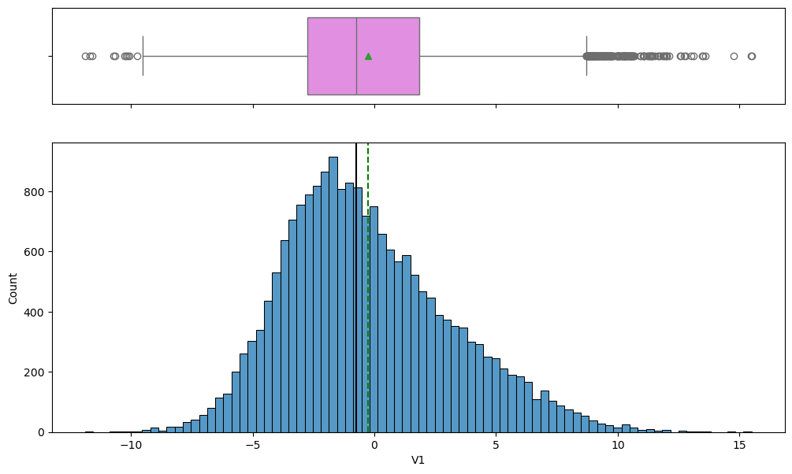

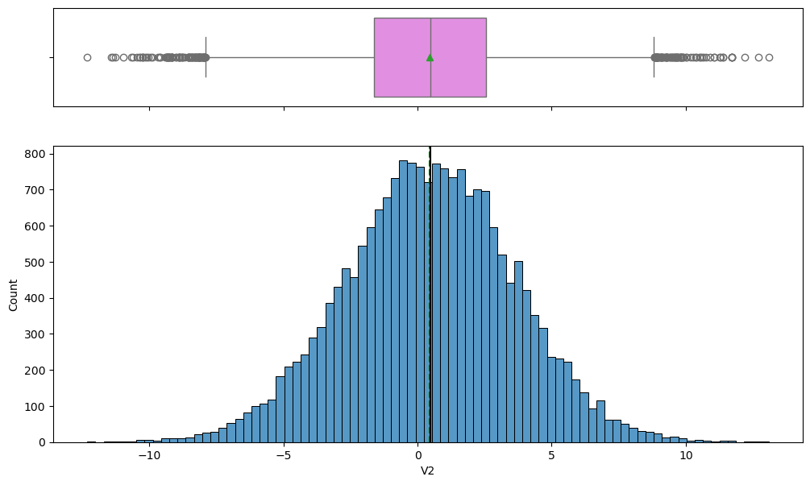

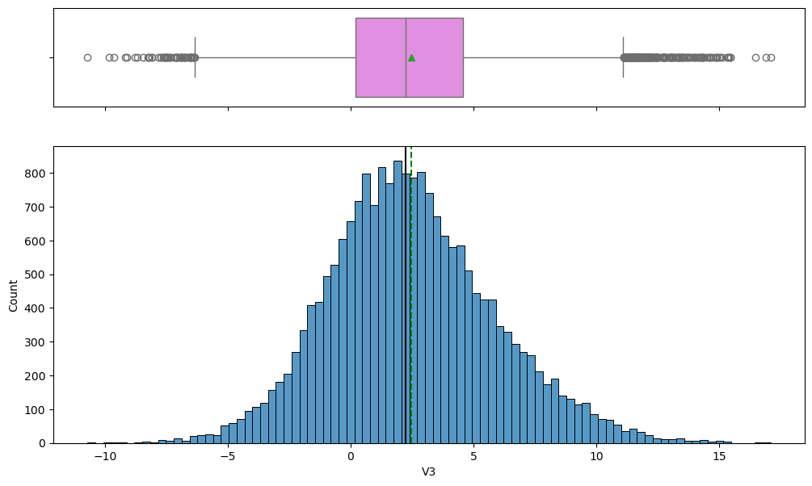

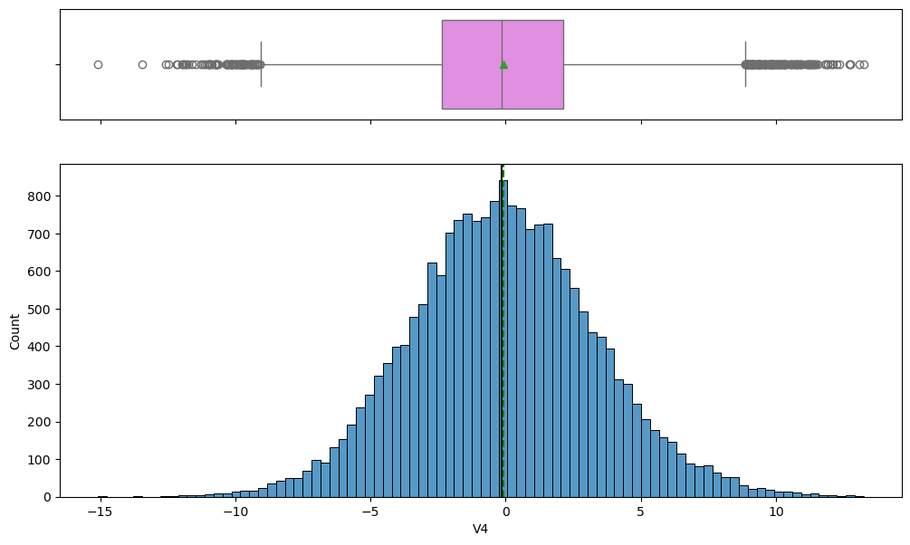

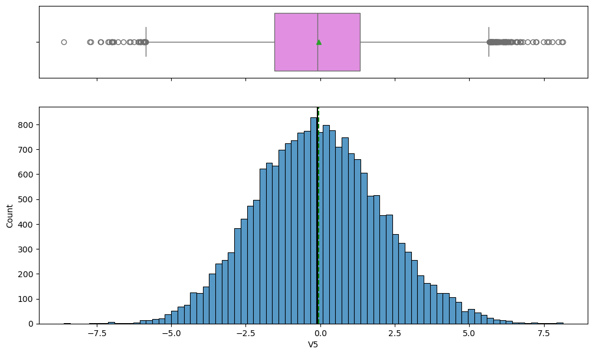

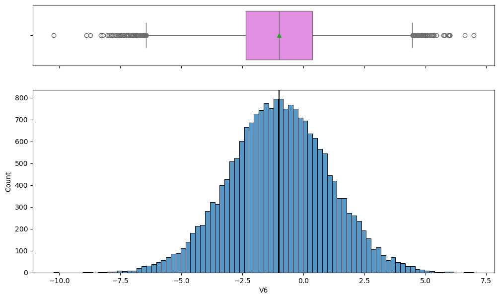

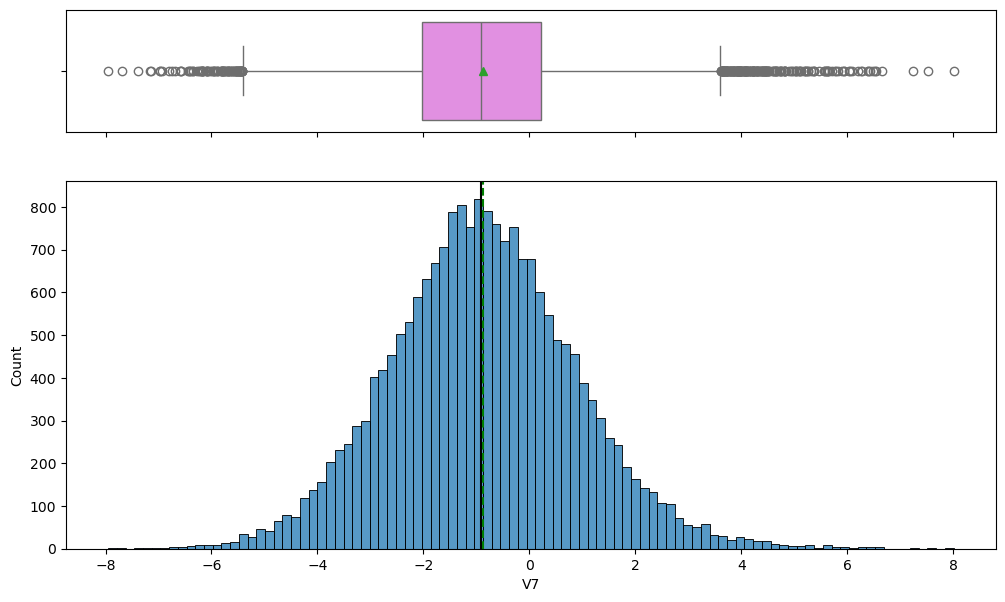

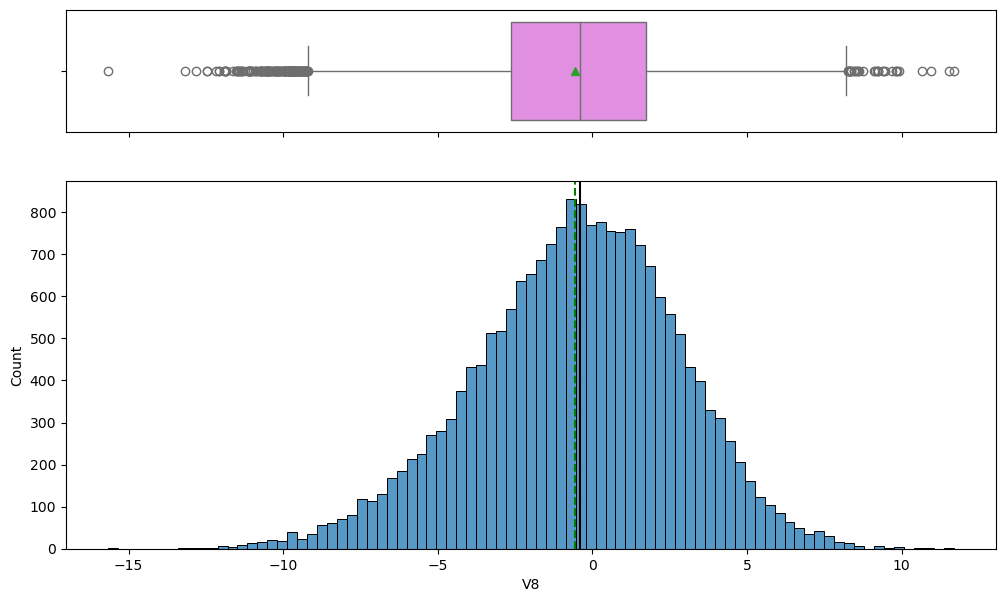

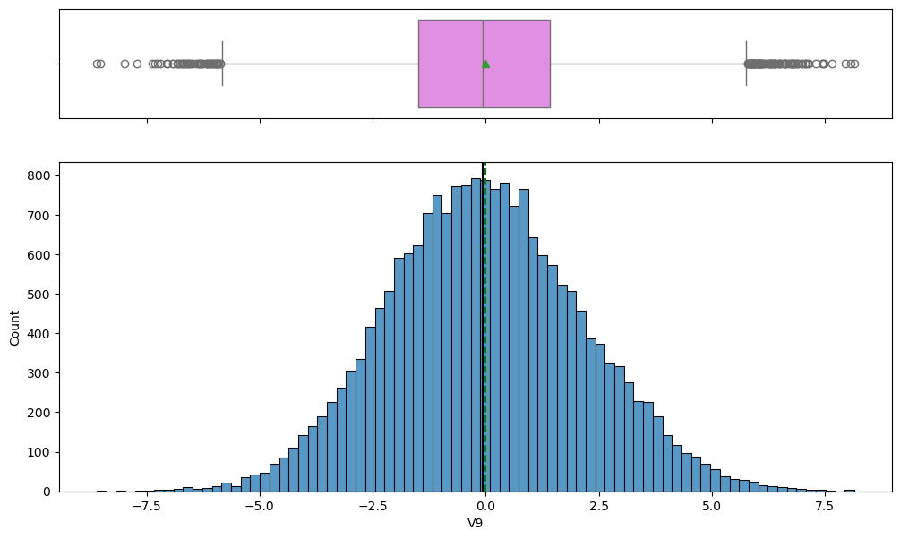

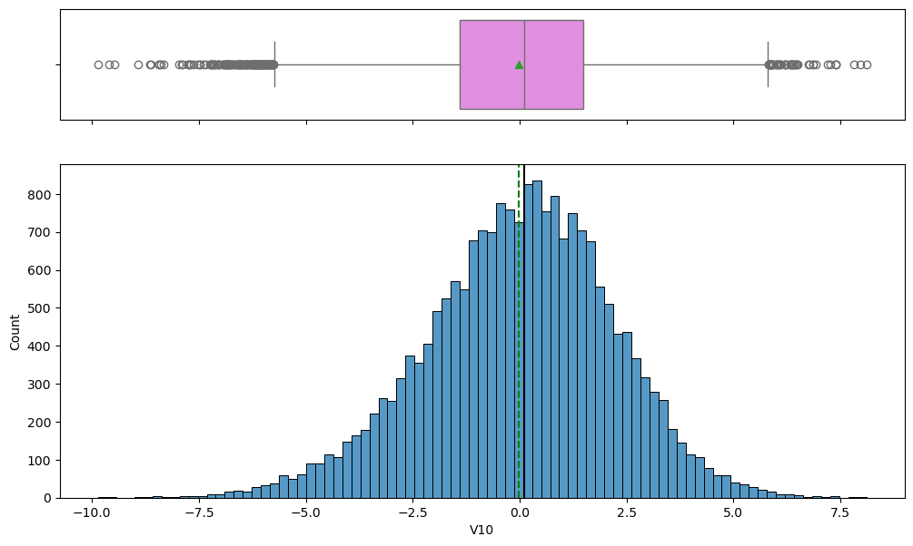

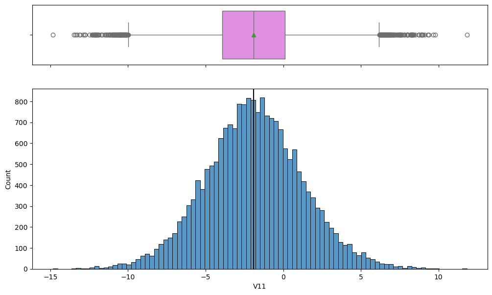

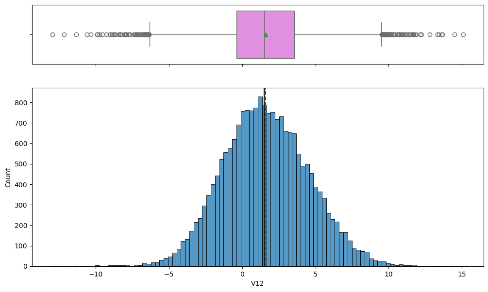

[29 more figures not shown]

```python
for feature in df.columns:
    histogram_boxplot(df, feature, figsize=(12, 7), kde=False, bins=None)
```

### Checking the distrubution of Target variable

```python
# For train data
df["Target"].value_counts(1)
```

```
Target
0    0.9445
1    0.0555
Name: proportion, dtype: float64
```

```python
# For test data
df_test["Target"].value_counts(1) # Complete the code to display the proportion of the target variable in the test data
```

```
Target
0    0.9436
1    0.0564
Name: proportion, dtype: float64
```

# Distribution of the Target Variable

## Observations

The distribution of the target variable in both the training and testing datasets is highly imbalanced.

### Training Dataset

- Class **0 (No Failure)**: **94.45%**
- Class **1 (Failure)**: **5.55%**

### Testing Dataset

- Class **0 (No Failure)**: **94.36%**
- Class **1 (Failure)**: **5.64%**

The proportions in the training and testing datasets are very similar, indicating that both datasets follow a consistent distribution.

This means:

- turbine failures are relatively rare events,
- while the majority of turbines operate under normal conditions.

# Why This Is Important

Analyzing the distribution of the target variable is extremely important because:

## 1. The Dataset Is Highly Imbalanced

The model will be trained on a dataset where the majority class ("No Failure") dominates the observations.

Without proper handling:

- the model may become biased toward predicting the majority class,
- resulting in poor failure detection performance.

For example:

- a model predicting only "No Failure" could still achieve over 94% accuracy,
- but it would completely fail to identify actual turbine failures.

## 2. Accuracy Alone Becomes Misleading

Because failure events are rare:

- accuracy is not an appropriate standalone evaluation metric.

More meaningful evaluation metrics include:

- Recall,
- Precision,
- F1-score,
- ROC-AUC,
- and confusion matrix analysis.

These metrics provide a better understanding of how effectively the model identifies failures.

## 3. Class Imbalance Affects Model Optimization

The imbalance suggests that additional techniques may be needed during model development, such as:

- class weighting,
- SMOTE (Synthetic Minority Oversampling),
- threshold tuning,
- or specialized evaluation strategies.

These methods help improve the model’s ability to detect rare failure events.

# Business Impact

The target variable distribution has major business implications because turbine failures are rare but extremely costly.

## Cost of False Negatives

A False Negative occurs when:

- the model predicts "No Failure,"
- but the turbine actually fails.

This can lead to:

- generator breakdown,
- expensive replacement costs,
- operational downtime,
- loss of energy production,
- and increased maintenance expenses.

False Negatives are the most critical business risk in this project.

## Cost of False Positives

A False Positive occurs when:

- the model predicts failure,
- but the turbine is actually healthy.

This leads to:

- inspection costs,
- unnecessary maintenance checks,
- and minor operational inefficiencies.

However, False Positives are significantly less expensive than missed failures.

# Business Objective

From a business perspective, the primary objective is:

- to detect as many true failures as possible,
- minimize False Negatives,
- and reduce costly turbine breakdowns.

Therefore, the final predictive maintenance model should prioritize:

- high Recall,
- strong failure detection capability,
- and early identification of abnormal turbine behavior.

The ultimate goal is to help ReneWind transition from:

- reactive maintenance

to:

- proactive predictive maintenance.

## Bivariate Analysis

### Correlation Check

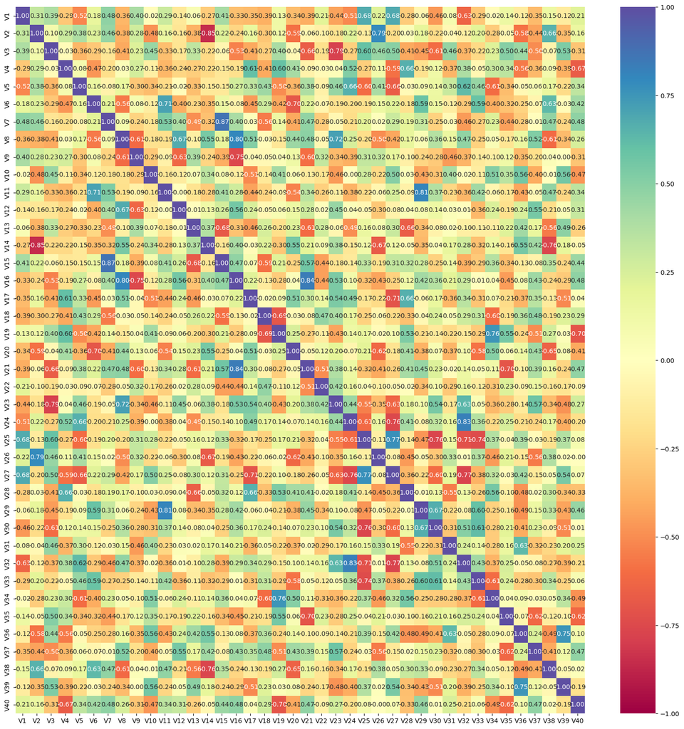

```python
cols_list = df.select_dtypes(include=np.number).columns.tolist()
cols_list.remove("Target")

plt.figure(figsize=(20, 20))
sns.heatmap(
    df[cols_list].corr(), annot=True, vmin=-1, vmax=1, fmt=".2f", cmap="Spectral"
)
plt.show()
```

# Bivariate Analysis – Correlation Heatmap

## Observations from the Correlation Matrix

The heatmap displays the pairwise correlation coefficients between all numerical variables (V1–V40).

Correlation values range from:

- **+1** → strong positive relationship
- **-1** → strong negative relationship
- **0** → little or no linear relationship

### Key Observations

- Most variables show:
  - weak to moderate correlations,
  - indicating that many sensor variables capture different operational characteristics of the turbines.
- Several variable pairs exhibit:
  - strong positive correlations,
  - where variables increase together.

Examples include:

- V1 with V25 and V27
- V11 with V29
- V24 with V32
- V30 with V33
- Some variable pairs show strong negative correlations, meaning:
  - as one variable increases, the other decreases.

# Why Correlation Analysis Is Important in EDA

Correlation analysis is one of the most important parts of Exploratory Data Analysis because it helps identify relationships between variables.

## 1. Detecting Multicollinearity

Highly correlated variables may contain redundant information.

This is important because:

- multicollinearity can negatively affect certain machine learning models,
- especially linear models such as Logistic Regression.

Strong multicollinearity may:

- reduce model interpretability,
- increase model instability,
- and inflate coefficient importance.

## 2. Understanding Relationships Between Sensors

Correlation analysis helps identify:

- which turbine sensors move together,
- which variables behave independently,
- and which measurements may represent similar operational conditions.

This provides insight into:

- turbine mechanics,
- operational dependencies,
- and system interactions.

## 3. Supporting Feature Selection

Highly correlated features may:

- provide overlapping information,
- or contribute limited additional predictive value.

This analysis helps determine whether:

- feature reduction,
- dimensionality reduction,
- or feature engineering

may improve model performance.

## 4. Improving Machine Learning Performance

Understanding variable relationships helps:

- reduce noise,
- improve model stability,
- and optimize preprocessing decisions.

For example:

- strongly correlated features may benefit tree-based models,
- while redundant variables may hurt simpler linear models.

# Business Interpretation

From a business and operational perspective:

- Correlated variables may represent connected turbine subsystems such as:
  - temperature,
  - pressure,
  - vibration,
  - rotational speed,
  - or generator load.
- Strong positive correlations may indicate:
  - components that react together during normal operation,
  - or shared operational behavior across turbine systems.
- Strong negative correlations may indicate:
  - balancing mechanisms,
  - inverse operational relationships,
  - or compensating system responses.
- Changes in correlated sensor groups may help identify:
  - abnormal turbine conditions,
  - mechanical degradation,
  - or early failure patterns.

# Business Impact

Understanding correlations between turbine sensors can significantly improve predictive maintenance strategies.

## Operational Benefits

A better understanding of sensor relationships can help:

- detect abnormal operating conditions earlier,
- improve failure prediction accuracy,
- reduce unnecessary maintenance inspections,
- and optimize monitoring systems.

## Maintenance Optimization

Correlation analysis may help engineers:

- identify which sensors provide the most useful operational information,
- reduce redundant monitoring,
- and focus attention on high-risk turbine components.

## Cost Reduction

Improved predictive modeling can help reduce:

- generator replacement costs,
- unplanned downtime,
- operational interruptions,
- and maintenance expenses.

# Overall Conclusion

The correlation heatmap suggests that:

- the dataset contains meaningful relationships between turbine sensor variables,
- moderate-to-strong correlations exist between several features,
- and the data appears suitable for machine learning modeling.

The absence of excessive perfect correlations is beneficial because:

- the model is less likely to suffer from severe redundancy issues,
- while still retaining useful inter-variable relationships that may improve turbine failure prediction.

# **Data Preprocessing**

## Data Preparation for Modeling

```python
# Dividing train data into X and y
X = data.drop(columns = ["Target"] , axis=1) # Complete the code to remove the column named 'Target'
y = data["Target"] # Complete the code to select the column named 'Target'
```

**Since we already have a separate test set, we don't need to divide data into train, valiation and test**

```python
# Splitting data into training and validation set:

X_train, X_val, y_train, y_val = train_test_split(
    X, y, test_size=0.2, random_state=1, stratify=y # Complete the code to define the test size
)
```

```python
# Checking the number of rows and columns in the X_train data
X_train.shape
```

```
(16000, 40)
```

```python
# Checking the number of rows and columns in the X_val data
X_val.shape
```

```
(4000, 40)
```

```python
# Dividing test data into X_test and y_test
X_test = data_test.drop(columns = ['Target'] , axis= 1) # Complete the code to remove the target column
y_test = data_test["Target"] # Complete the code to select the target column
```

```python
# Checking the number of rows and columns in the X_test data
X_test.shape
```

```
(5000, 40)
```

# Data Preparation for Modeling

## Observations

The dataset was successfully divided into training, validation, and testing datasets for machine learning model development.

### Training Dataset

- Shape: **(16000, 40)**
- Contains:
  - 16,000 observations
  - 40 predictor variables

### Validation Dataset

- Shape: **(4000, 40)**
- Contains:
  - 4,000 observations
  - 40 predictor variables

### Testing Dataset

- Shape: **(5000, 40)**
- Contains:
  - 5,000 observations
  - 40 predictor variables

The target variable (`Target`) was successfully separated from the predictor variables before model training.

# Why This Is Important

Preparing the data correctly before modeling is one of the most critical steps in machine learning.

## 1. Separation of Features and Target Variable

The predictor variables (`X`) and target variable (`y`) were separated to:

- allow the model to learn relationships between sensor readings and turbine failures,
- avoid including the target variable as an input feature,
- and ensure proper supervised learning.

This is necessary because the target variable represents the output the model is trying to predict.

## 2. Splitting the Dataset

The training dataset was split into:

- training data (80%)
- validation data (20%)

This is important because:

### Training Data

The model learns patterns from the training dataset.

### Validation Data

The validation dataset is used to:

- evaluate model performance during training,
- tune hyperparameters,
- compare models,
- and prevent overfitting.

The separate testing dataset is reserved for final unbiased model evaluation.

## 3. Stratified Sampling

[output not shown]

- There were few missing values in V1 and V2, we will impute them using the median.
- And to avoid data leakage we will impute missing values after splitting train data into train and validation sets.

```python
imputer = SimpleImputer(strategy="median")
```

```python
# Fit and transform the train data
X_train = pd.DataFrame(imputer.fit_transform(X_train), columns=X_train.columns)

# Transform the validation data
X_val = pd.DataFrame(imputer.transform(X_val), columns=X_train.columns)    # Complete the code to impute missing values in the validation set while accounting for data leakage

# Transform the test data
X_test = pd.DataFrame(imputer.transform(X_test), columns=X_train.columns)    # Complete the code to impute missing values in the test set while accounting for data leakage
```

```python
# Checking that no column has missing values in train or test sets
print(X_train.isna().sum())
print("-" * 30)
print(X_val.isna().sum())
print("-" * 30)
print(X_test.isna().sum())
```

```
V1     0
V2     0
V3     0
V4     0
V5     0
V6     0
V7     0
V8     0
V9     0
V10    0
V11    0
V12    0
V13    0
V14    0
V15    0
V16    0
V17    0
V18    0
V19    0
V20    0
V21    0
V22    0
V23    0
V24    0
V25    0
V26    0
V27    0
V28    0
V29    0
V30    0
V31    0
V32    0
V33    0
V34    0
V35    0
V36    0
V37    0
V38    0
V39    0
V40    0
```

[output cut: 70 more lines]

```
V27    0
V28    0
V29    0
V30    0
V31    0
V32    0
V33    0
V34    0
V35    0
V36    0
V37    0
V38    0
V39    0
V40    0
dtype: int64
```

```python
y_train = y_train.to_numpy()
y_val = y_val.to_numpy()
y_test = y_test.to_numpy()
```

# Missing Value Treatment

## What This Output Says

The missing values in the dataset were handled using **median imputation**.

Earlier analysis showed that only **V1** and **V2** had missing values. After applying the imputer, the output shows that every column in the training, validation, and test datasets now has **0 missing values**.

This confirms that missing value treatment was completed successfully.

# Why This Is Important

Missing value treatment is important because:

- most machine learning models cannot process missing values directly,
- missing values can cause errors during model training,
- incomplete data can reduce model performance,
- and proper imputation helps maintain consistency across train, validation, and test datasets.

Median imputation was used because it is more robust to outliers than mean imputation. This is useful here because the EDA showed that several sensor variables contain outliers.

# Preventing Data Leakage

The imputer was fitted only on the training data using:

```
imputer.fit_transform(X_train)
```

# **Model Building**

## Model Evaluation Criterion

**We are now done with pre-processing and evaluation criterion, so let's start building the model.**

## Utility Functions

```python
def plot(history, name):
    """
    Function to plot loss/accuracy

    history: an object which stores the metrics and losses.
    name: can be one of Loss or Accuracy
    """
    fig, ax = plt.subplots() #Creating a subplot with figure and axes.
    plt.plot(history.history[name]) #Plotting the train accuracy or train loss
    plt.plot(history.history['val_'+name]) #Plotting the validation accuracy or validation loss

    plt.title('Model ' + name.capitalize()) #Defining the title of the plot.
    plt.ylabel(name.capitalize()) #Capitalizing the first letter.
    plt.xlabel('Epoch') #Defining the label for the x-axis.
    fig.legend(['Train', 'Validation'], loc="outside right upper") #Defining the legend, loc controls the position of the legend.
```

```python
# defining a function to compute different metrics to check performance of a classification model built using statsmodels
def model_performance_classification(
    model, predictors, target, threshold=0.5
):
    """
    Function to compute different metrics to check classification model performance

    model: classifier
    predictors: independent variables
    target: dependent variable
    threshold: threshold for classifying the observation as class 1
    """

    # checking which probabilities are greater than threshold
    pred = model.predict(predictors) > threshold
    # pred_temp = model.predict(predictors) > threshold
    # # rounding off the above values to get classes
    # pred = np.round(pred_temp)

    acc = accuracy_score(target, pred)  # to compute Accuracy
    recall = recall_score(target, pred, average='macro')  # to compute Recall
    precision = precision_score(target, pred, average='macro')  # to compute Precision
    f1 = f1_score(target, pred, average='macro')  # to compute F1-score

    # creating a dataframe of metrics
    df_perf = pd.DataFrame(
        {"Accuracy": acc, "Recall": recall, "Precision": precision, "F1 Score": f1,}, index = [0]
    )

    return df_perf
```

## Initial Model Building (Model 0)

```python
# defining the batch size and # epochs upfront as we'll be using the same values for all models
epochs = 56    # Complete the code to enter the number of epochs to be used in all models
batch_size = 256    # Complete the code to enter the batch size to be used in all models
```

```python
# clears the current Keras session, resetting all layers and models previously created, freeing up memory and resources.
tf.keras.backend.clear_session()
```

```python
#Initializing the neural network
model_0 = Sequential()
model_0.add(Dense( 64 ,activation="relu",input_dim=X_train.shape[1])) # Complete the code to define the number of neurons and the activation function
model_0.add(Dense( 1 ,activation="sigmoid")) # Complete the code to define the number of neurons in the output layer
```

```python
model_0.summary()
```

```
Model: "sequential"
```

```
┏━━━━━━━━━━━━━━━━━━━━━━━━━━━━━━━━━┳━━━━━━━━━━━━━━━━━━━━━━━━┳━━━━━━━━━━━━━━━┓
┃ Layer (type)                    ┃ Output Shape           ┃       Param # ┃
┡━━━━━━━━━━━━━━━━━━━━━━━━━━━━━━━━━╇━━━━━━━━━━━━━━━━━━━━━━━━╇━━━━━━━━━━━━━━━┩
│ dense (Dense)                   │ (None, 64)             │         2,624 │
├─────────────────────────────────┼────────────────────────┼───────────────┤
│ dense_1 (Dense)                 │ (None, 1)              │            65 │
└─────────────────────────────────┴────────────────────────┴───────────────┘
```

```
 Total params: 2,689 (10.50 KB)
```

```
 Trainable params: 2,689 (10.50 KB)
```

```
 Non-trainable params: 0 (0.00 B)
```

```python
optimizer = tf.keras.optimizers.SGD()   # defining SGD as the optimizer to be used
# model_0.compile(loss='binary_crossentropy', optimizer=optimizer, metrics = ['accuracy']) ## Uncomment this line in case the metric of choice is Accuracy
# model_0.compile(loss='binary_crossentropy', optimizer=optimizer, metrics = ['Precision']) ## Uncomment this line in case the metric of choice is Precision
# model_0.compile(loss='binary_crossentropy', optimizer=optimizer, metrics = ['Recall']) ## Uncomment this line in case the metric of choice is Recall
# model_0.compile(loss='binary_crossentropy', optimizer=optimizer, metrics = ['f1_score']) ## Uncomment this line in case the metric of choice is F1 Score
```

```python
optimizer = tf.keras.optimizers.SGD()

model_0.compile(
    loss="binary_crossentropy",
    optimizer=optimizer,
    metrics=["Recall"]
)
```

```python
start = time.time()

history = model_0.fit(
    X_train,
    y_train,
    validation_data=(X_val, y_val),
    batch_size=batch_size,
    epochs=epochs
)

end = time.time()

print("Time taken in seconds ", end - start)
```

```
63/63 ━━━━━━━━━━━━━━━━━━━━ 0s 2ms/step - Recall: 0.0890 - loss: 0.2253 - val_Recall: 0.1892 - val_loss: 0.1616
63/63 ━━━━━━━━━━━━━━━━━━━━ 0s 509us/step - Recall: 0.2815 - loss: 0.1524 - val_Recall: 0.3829 - val_loss: 0.1338
63/63 ━━━━━━━━━━━━━━━━━━━━ 0s 565us/step - Recall: 0.4178 - loss: 0.1312 - val_Recall: 0.5045 - val_loss: 0.1215
63/63 ━━━━━━━━━━━━━━━━━━━━ 0s 577us/step - Recall: 0.4797 - loss: 0.1193 - val_Recall: 0.5270 - val_loss: 0.1126
63/63 ━━━━━━━━━━━━━━━━━━━━ 0s 584us/step - Recall: 0.5214 - loss: 0.1111 - val_Recall: 0.5811 - val_loss: 0.1066
63/63 ━━━━━━━━━━━━━━━━━━━━ 0s 572us/step - Recall: 0.5586 - loss: 0.1051 - val_Recall: 0.6216 - val_loss: 0.1022
63/63 ━━━━━━━━━━━━━━━━━━━━ 0s 560us/step - Recall: 0.5777 - loss: 0.1003 - val_Recall: 0.6171 - val_loss: 0.0983
63/63 ━━━━━━━━━━━━━━━━━━━━ 0s 575us/step - Recall: 0.6002 - loss: 0.0964 - val_Recall: 0.6351 - val_loss: 0.0953
63/63 ━━━━━━━━━━━━━━━━━━━━ 0s 598us/step - Recall: 0.6160 - loss: 0.0932 - val_Recall: 0.6532 - val_loss: 0.0929
63/63 ━━━━━━━━━━━━━━━━━━━━ 0s 592us/step - Recall: 0.6351 - loss: 0.0905 - val_Recall: 0.6757 - val_loss: 0.0908
63/63 ━━━━━━━━━━━━━━━━━━━━ 0s 527us/step - Recall: 0.6453 - loss: 0.0881 - val_Recall: 0.6982 - val_loss: 0.0891
63/63 ━━━━━━━━━━━━━━━━━━━━ 0s 523us/step - Recall: 0.6622 - loss: 0.0861 - val_Recall: 0.6982 - val_loss: 0.0875
63/63 ━━━━━━━━━━━━━━━━━━━━ 0s 530us/step - Recall: 0.6723 - loss: 0.0843 - val_Recall: 0.7027 - val_loss: 0.0861
63/63 ━━━━━━━━━━━━━━━━━━━━ 0s 520us/step - Recall: 0.6869 - loss: 0.0828 - val_Recall: 0.7027 - val_loss: 0.0848
63/63 ━━━━━━━━━━━━━━━━━━━━ 0s 536us/step - Recall: 0.6982 - loss: 0.0814 - val_Recall: 0.7027 - val_loss: 0.0836
63/63 ━━━━━━━━━━━━━━━━━━━━ 0s 541us/step - Recall: 0.7005 - loss: 0.0801 - val_Recall: 0.7162 - val_loss: 0.0827
63/63 ━━━━━━━━━━━━━━━━━━━━ 0s 547us/step - Recall: 0.7106 - loss: 0.0789 - val_Recall: 0.7252 - val_loss: 0.0818
63/63 ━━━━━━━━━━━━━━━━━━━━ 0s 518us/step - Recall: 0.7173 - loss: 0.0778 - val_Recall: 0.7387 - val_loss: 0.0810
63/63 ━━━━━━━━━━━━━━━━━━━━ 0s 535us/step - Recall: 0.7241 - loss: 0.0769 - val_Recall: 0.7387 - val_loss: 0.0803
63/63 ━━━━━━━━━━━━━━━━━━━━ 0s 515us/step - Recall: 0.7275 - loss: 0.0759 - val_Recall: 0.7432 - val_loss: 0.0796
63/63 ━━━━━━━━━━━━━━━━━━━━ 0s 548us/step - Recall: 0.7354 - loss: 0.0751 - val_Recall: 0.7387 - val_loss: 0.0789
63/63 ━━━━━━━━━━━━━━━━━━━━ 0s 510us/step - Recall: 0.7342 - loss: 0.0743 - val_Recall: 0.7387 - val_loss: 0.0783
63/63 ━━━━━━━━━━━━━━━━━━━━ 0s 559us/step - Recall: 0.7399 - loss: 0.0736 - val_Recall: 0.7568 - val_loss: 0.0778
63/63 ━━━━━━━━━━━━━━━━━━━━ 0s 502us/step - Recall: 0.7477 - loss: 0.0729 - val_Recall: 0.7568 - val_loss: 0.0772
63/63 ━━━━━━━━━━━━━━━━━━━━ 0s 502us/step - Recall: 0.7511 - loss: 0.0723 - val_Recall: 0.7613 - val_loss: 0.0768
63/63 ━━━━━━━━━━━━━━━━━━━━ 0s 513us/step - Recall: 0.7568 - loss: 0.0717 - val_Recall: 0.7658 - val_loss: 0.0763
63/63 ━━━━━━━━━━━━━━━━━━━━ 0s 533us/step - Recall: 0.7601 - loss: 0.0711 - val_Recall: 0.7703 - val_loss: 0.0759
63/63 ━━━━━━━━━━━━━━━━━━━━ 0s 513us/step - Recall: 0.7646 - loss: 0.0706 - val_Recall: 0.7748 - val_loss: 0.0755
63/63 ━━━━━━━━━━━━━━━━━━━━ 0s 520us/step - Recall: 0.7680 - loss: 0.0700 - val_Recall: 0.7703 - val_loss: 0.0751
63/63 ━━━━━━━━━━━━━━━━━━━━ 0s 547us/step - Recall: 0.7703 - loss: 0.0696 - val_Recall: 0.7793 - val_loss: 0.0748
63/63 ━━━━━━━━━━━━━━━━━━━━ 0s 506us/step - Recall: 0.7725 - loss: 0.0691 - val_Recall: 0.7748 - val_loss: 0.0743
63/63 ━━━━━━━━━━━━━━━━━━━━ 0s 524us/step - Recall: 0.7714 - loss: 0.0686 - val_Recall: 0.7748 - val_loss: 0.0740
63/63 ━━━━━━━━━━━━━━━━━━━━ 0s 584us/step - Recall: 0.7714 - loss: 0.0681 - val_Recall: 0.7838 - val_loss: 0.0740
63/63 ━━━━━━━━━━━━━━━━━━━━ 0s 488us/step - Recall: 0.7804 - loss: 0.0677 - val_Recall: 0.7748 - val_loss: 0.0733
63/63 ━━━━━━━━━━━━━━━━━━━━ 0s 491us/step - Recall: 0.7770 - loss: 0.0673 - val_Recall: 0.7838 - val_loss: 0.0731
63/63 ━━━━━━━━━━━━━━━━━━━━ 0s 525us/step - Recall: 0.7815 - loss: 0.0669 - val_Recall: 0.7793 - val_loss: 0.0728
63/63 ━━━━━━━━━━━━━━━━━━━━ 0s 491us/step - Recall: 0.7793 - loss: 0.0665 - val_Recall: 0.7883 - val_loss: 0.0726
63/63 ━━━━━━━━━━━━━━━━━━━━ 0s 522us/step - Recall: 0.7838 - loss: 0.0662 - val_Recall: 0.7883 - val_loss: 0.0722
```

[output cut: 19 more lines]

```python
start = time.time()
history = model_0.fit(X_train, y_train, validation_data=(X_val,y_val) , batch_size=batch_size, epochs=epochs)
end=time.time()
```

```
63/63 ━━━━━━━━━━━━━━━━━━━━ 0s 1ms/step - Recall: 0.8029 - loss: 0.0607 - val_Recall: 0.7973 - val_loss: 0.0686
63/63 ━━━━━━━━━━━━━━━━━━━━ 0s 558us/step - Recall: 0.8063 - loss: 0.0605 - val_Recall: 0.7973 - val_loss: 0.0684
63/63 ━━━━━━━━━━━━━━━━━━━━ 0s 521us/step - Recall: 0.8063 - loss: 0.0603 - val_Recall: 0.7973 - val_loss: 0.0682
63/63 ━━━━━━━━━━━━━━━━━━━━ 0s 552us/step - Recall: 0.8041 - loss: 0.0601 - val_Recall: 0.7973 - val_loss: 0.0682
63/63 ━━━━━━━━━━━━━━━━━━━━ 0s 534us/step - Recall: 0.8074 - loss: 0.0598 - val_Recall: 0.7973 - val_loss: 0.0680
63/63 ━━━━━━━━━━━━━━━━━━━━ 0s 845us/step - Recall: 0.8074 - loss: 0.0597 - val_Recall: 0.7973 - val_loss: 0.0679
63/63 ━━━━━━━━━━━━━━━━━━━━ 0s 508us/step - Recall: 0.8063 - loss: 0.0595 - val_Recall: 0.7973 - val_loss: 0.0678
63/63 ━━━━━━━━━━━━━━━━━━━━ 0s 557us/step - Recall: 0.8086 - loss: 0.0593 - val_Recall: 0.7973 - val_loss: 0.0676
63/63 ━━━━━━━━━━━━━━━━━━━━ 0s 539us/step - Recall: 0.8108 - loss: 0.0591 - val_Recall: 0.7973 - val_loss: 0.0675
63/63 ━━━━━━━━━━━━━━━━━━━━ 0s 511us/step - Recall: 0.8086 - loss: 0.0589 - val_Recall: 0.7973 - val_loss: 0.0674
63/63 ━━━━━━━━━━━━━━━━━━━━ 0s 553us/step - Recall: 0.8119 - loss: 0.0587 - val_Recall: 0.7973 - val_loss: 0.0672
63/63 ━━━━━━━━━━━━━━━━━━━━ 0s 509us/step - Recall: 0.8131 - loss: 0.0585 - val_Recall: 0.7973 - val_loss: 0.0671
63/63 ━━━━━━━━━━━━━━━━━━━━ 0s 552us/step - Recall: 0.8119 - loss: 0.0583 - val_Recall: 0.7973 - val_loss: 0.0670
63/63 ━━━━━━━━━━━━━━━━━━━━ 0s 546us/step - Recall: 0.8119 - loss: 0.0582 - val_Recall: 0.7973 - val_loss: 0.0669
63/63 ━━━━━━━━━━━━━━━━━━━━ 0s 539us/step - Recall: 0.8142 - loss: 0.0580 - val_Recall: 0.7973 - val_loss: 0.0668
63/63 ━━━━━━━━━━━━━━━━━━━━ 0s 523us/step - Recall: 0.8142 - loss: 0.0578 - val_Recall: 0.7973 - val_loss: 0.0667
63/63 ━━━━━━━━━━━━━━━━━━━━ 0s 582us/step - Recall: 0.8142 - loss: 0.0577 - val_Recall: 0.7973 - val_loss: 0.0666
63/63 ━━━━━━━━━━━━━━━━━━━━ 0s 534us/step - Recall: 0.8164 - loss: 0.0575 - val_Recall: 0.8018 - val_loss: 0.0665
63/63 ━━━━━━━━━━━━━━━━━━━━ 0s 535us/step - Recall: 0.8187 - loss: 0.0573 - val_Recall: 0.8018 - val_loss: 0.0664
63/63 ━━━━━━━━━━━━━━━━━━━━ 0s 542us/step - Recall: 0.8164 - loss: 0.0572 - val_Recall: 0.8018 - val_loss: 0.0663
63/63 ━━━━━━━━━━━━━━━━━━━━ 0s 521us/step - Recall: 0.8198 - loss: 0.0570 - val_Recall: 0.8018 - val_loss: 0.0662
63/63 ━━━━━━━━━━━━━━━━━━━━ 0s 515us/step - Recall: 0.8164 - loss: 0.0569 - val_Recall: 0.8063 - val_loss: 0.0661
63/63 ━━━━━━━━━━━━━━━━━━━━ 0s 569us/step - Recall: 0.8198 - loss: 0.0567 - val_Recall: 0.8108 - val_loss: 0.0661
63/63 ━━━━━━━━━━━━━━━━━━━━ 0s 540us/step - Recall: 0.8221 - loss: 0.0566 - val_Recall: 0.8108 - val_loss: 0.0660
63/63 ━━━━━━━━━━━━━━━━━━━━ 0s 538us/step - Recall: 0.8221 - loss: 0.0564 - val_Recall: 0.8108 - val_loss: 0.0658
63/63 ━━━━━━━━━━━━━━━━━━━━ 0s 526us/step - Recall: 0.8176 - loss: 0.0563 - val_Recall: 0.8108 - val_loss: 0.0658
63/63 ━━━━━━━━━━━━━━━━━━━━ 0s 512us/step - Recall: 0.8232 - loss: 0.0561 - val_Recall: 0.8108 - val_loss: 0.0657
63/63 ━━━━━━━━━━━━━━━━━━━━ 0s 570us/step - Recall: 0.8221 - loss: 0.0560 - val_Recall: 0.8108 - val_loss: 0.0656
63/63 ━━━━━━━━━━━━━━━━━━━━ 0s 550us/step - Recall: 0.8187 - loss: 0.0559 - val_Recall: 0.8108 - val_loss: 0.0656
63/63 ━━━━━━━━━━━━━━━━━━━━ 0s 559us/step - Recall: 0.8221 - loss: 0.0557 - val_Recall: 0.8108 - val_loss: 0.0654
63/63 ━━━━━━━━━━━━━━━━━━━━ 0s 579us/step - Recall: 0.8221 - loss: 0.0556 - val_Recall: 0.8153 - val_loss: 0.0654
63/63 ━━━━━━━━━━━━━━━━━━━━ 0s 511us/step - Recall: 0.8221 - loss: 0.0555 - val_Recall: 0.8153 - val_loss: 0.0653
63/63 ━━━━━━━━━━━━━━━━━━━━ 0s 553us/step - Recall: 0.8232 - loss: 0.0553 - val_Recall: 0.8153 - val_loss: 0.0652
63/63 ━━━━━━━━━━━━━━━━━━━━ 0s 545us/step - Recall: 0.8221 - loss: 0.0552 - val_Recall: 0.8153 - val_loss: 0.0652
63/63 ━━━━━━━━━━━━━━━━━━━━ 0s 542us/step - Recall: 0.8232 - loss: 0.0551 - val_Recall: 0.8153 - val_loss: 0.0651
63/63 ━━━━━━━━━━━━━━━━━━━━ 0s 548us/step - Recall: 0.8221 - loss: 0.0550 - val_Recall: 0.8153 - val_loss: 0.0650
63/63 ━━━━━━━━━━━━━━━━━━━━ 0s 522us/step - Recall: 0.8243 - loss: 0.0548 - val_Recall: 0.8153 - val_loss: 0.0650
```

[output cut: 19 more lines]

```python
print("Time taken in seconds ",end-start)
```

```
Time taken in seconds  2.328244924545288
```

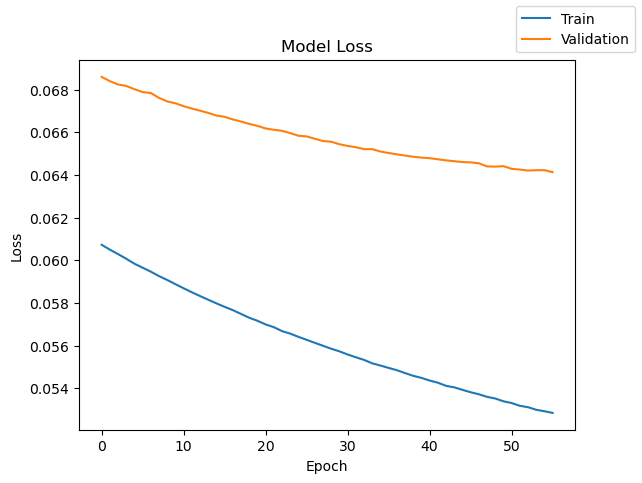

```python
plot(history,'loss')
```

```python
model_0_train_perf = model_performance_classification(model_0, X_train, y_train)
model_0_train_perf
```

```
500/500 ━━━━━━━━━━━━━━━━━━━━ 0s 137us/step
```

|  | Accuracy | Recall | Precision | F1 Score |
| --- | --- | --- | --- | --- |
| 0 | 0.989313 | 0.913786 | 0.982432 | 0.945145 |

```python
model_0_val_perf = model_performance_classification(model_0,X_val,y_val)
model_0_val_perf
```

```
125/125 ━━━━━━━━━━━━━━━━━━━━ 0s 233us/step
```

|  | Accuracy | Recall | Precision | F1 Score |
| --- | --- | --- | --- | --- |
| 0 | 0.98875 | 0.911368 | 0.97901 | 0.942291 |

Let's check the classification reports.

```python
y_train_pred_0 = model_0.predict(X_train)
y_val_pred_0 = model_0.predict(X_val)
```

```
500/500 ━━━━━━━━━━━━━━━━━━━━ 0s 158us/step
125/125 ━━━━━━━━━━━━━━━━━━━━ 0s 151us/step
```

```python
print("Classification Report - Train data Model_0",end="\n\n")
cr_train_model_0 = classification_report(y_train,y_train_pred_0>0.5)
print(cr_train_model_0)
```

```
Classification Report - Train data Model_0

              precision    recall  f1-score   support

         0.0       0.99      1.00      0.99     15112
         1.0       0.97      0.83      0.90       888

    accuracy                           0.99     16000
   macro avg       0.98      0.91      0.95     16000
weighted avg       0.99      0.99      0.99     16000
```

```python
print("Classification Report - Validation data Model_0",end="\n\n")
cr_val_model_0 = classification_report(y_val,y_val_pred_0>0.5)
print(cr_val_model_0)
```

```
Classification Report - Validation data Model_0

              precision    recall  f1-score   support

         0.0       0.99      1.00      0.99      3778
         1.0       0.97      0.82      0.89       222

    accuracy                           0.99      4000
   macro avg       0.98      0.91      0.94      4000
weighted avg       0.99      0.99      0.99      4000
```

# Initial Neural Network Model (Model 0) – Results and Interpretation

# Model 0 Performance Results

The initial neural network model (Model 0) was evaluated using both the training and validation datasets.

# Training Dataset Results

| Metric | No Failure (0) | Failure (1) |
| --- | --- | --- |
| Precision | 0.99 | 0.97 |
| Recall | 1.00 | 0.83 |
| F1-Score | 0.99 | 0.90 |

### Overall Training Performance

- Accuracy: **99%**
- Macro Average Recall: **91%**
- Macro Average F1-Score: **95%**

# Validation Dataset Results

| Metric | No Failure (0) | Failure (1) |
| --- | --- | --- |
| Precision | 0.99 | 0.97 |
| Recall | 1.00 | 0.82 |
| F1-Score | 0.99 | 0.89 |

### Overall Validation Performance

- Accuracy: **99%**
- Macro Average Recall: **91%**
- Macro Average F1-Score: **94%**

# Interpretation of Results

## Strong Overall Model Performance

The model achieved extremely strong overall performance on both the training and validation datasets.

Key observations include:

- Overall accuracy reached approximately **99%**.
- Precision for failure prediction was approximately **97%**.
- Recall for failure prediction was approximately:
  - **83%** on training data,
  - **82%** on validation data.
- F1-score for the failure class remained high at approximately:
  - **0.90** for training,
  - **0.89** for validation.

These results indicate that the model successfully learned meaningful patterns from the turbine sensor data.

# Interpretation of Failure Detection Results

## Recall for Failure Class

The Recall score for class 1 (Failure) is particularly important.

A Recall of approximately:

- **82–83%**

means that:

- the model correctly identifies most turbine failures,
- but still misses approximately:
  - **17–18%** of actual failures.

This indicates good failure detection capability, although some failures remain undetected.

## Precision for Failure Class

The Precision score for failures is approximately:

- **97%**

This means:

- when the model predicts a turbine failure,
- it is usually correct.

As a result:

- the number of false alarms is relatively low,
- reducing unnecessary inspections and maintenance activity.

## F1-Score Interpretation

The F1-score combines:

- Precision,
- and Recall.

A high F1-score (~0.89–0.90) indicates that the model maintains a strong balance between:

- accurately identifying failures,
- and minimizing false alarms.

# Validation Results and Generalization

The training and validation results are very similar.

This is important because it suggests:

- the model is generalizing well,
- the learning process is stable,
- and there is limited evidence of severe overfitting.

A large gap between training and validation performance would indicate overfitting, but that is not strongly observed here.

# Why These Results Are Important

These results are important because the project focuses on predictive maintenance for wind turbines.

The model’s ability to correctly identify failures directly impacts:

- operational reliability,
- maintenance efficiency,
- and overall business cost reduction.

# Business Impact

## Reduced Generator Failure Risk

The model successfully identifies most turbine failures before complete breakdown occurs.

This enables:

- earlier intervention,
- preventive maintenance,
- and reduced catastrophic equipment failures.

## Lower Maintenance and Replacement Costs

Because failures can be identified early:

- generators can often be repaired instead of replaced.

This can significantly reduce:

- replacement expenses,
- emergency repair costs,
- and operational losses.

## Reduced Operational Downtime

Accurate failure prediction helps:

- minimize unexpected turbine shutdowns,
- improve equipment availability,
- and maintain stable energy production.

This improves operational efficiency and overall revenue stability.

## Reduced Unnecessary Maintenance

The high Precision score (~97%) means:

- most predicted failures are actual failures.

This reduces:

- unnecessary inspections,
- unnecessary maintenance activities,
- and wasted operational resources.

# Remaining Business Risk

Although the model performs very well overall, some actual failures are still missed.

These missed failures are called:

- False Negatives.

False Negatives remain the largest business risk because they may lead to:

- turbine breakdown,
- expensive generator replacement,
- operational downtime,
- and production losses.

Improving Recall further would help reduce this risk even more.

# Overall Conclusion

Model 0 provides a very strong baseline neural network model for predictive maintenance.

The results demonstrate:

- excellent overall accuracy,
- strong failure detection capability,
- high precision,
- stable validation performance,
- and strong business value potential.

The model shows significant promise for helping ReneWind:

- reduce maintenance costs,
- improve turbine reliability,
- minimize downtime,
- and transition toward proactive predictive maintenance.

```python
print("Classification Report - Validation data Model_0",end="\n\n")
cr_val_model_0 = classification_report(y_val,y_val_pred_0>0.5)
print(cr_val_model_0)
```

```
Classification Report - Validation data Model_0

              precision    recall  f1-score   support

         0.0       0.99      1.00      0.99      3778
         1.0       0.97      0.82      0.89       222

    accuracy                           0.99      4000
   macro avg       0.98      0.91      0.94      4000
weighted avg       0.99      0.99      0.99      4000
```

# **Model Performance Improvement**

## Model 1

- Let's try adding another layer to see if we can improve our model's performance.

```python
# clears the current Keras session, resetting all layers and models previously created, freeing up memory and resources.
tf.keras.backend.clear_session()
```

```python
#Initializing the neural network
model_1 = Sequential()
model_1.add(Dense(64 ,activation="relu",input_dim=X_train.shape[1])) # Complete the code to define the number of neurons and activation function
model_1.add(Dense( 32,activation="relu")) # Complete the code to define the number of neurons and activation function
model_1.add(Dense(1,activation="sigmoid")) # Complete the code to define the number of neurons in the output layer
```

```python
model_1.summary()
```

```
Model: "sequential"
```

```
┏━━━━━━━━━━━━━━━━━━━━━━━━━━━━━━━━━┳━━━━━━━━━━━━━━━━━━━━━━━━┳━━━━━━━━━━━━━━━┓
┃ Layer (type)                    ┃ Output Shape           ┃       Param # ┃
┡━━━━━━━━━━━━━━━━━━━━━━━━━━━━━━━━━╇━━━━━━━━━━━━━━━━━━━━━━━━╇━━━━━━━━━━━━━━━┩
│ dense (Dense)                   │ (None, 64)             │         2,624 │
├─────────────────────────────────┼────────────────────────┼───────────────┤
│ dense_1 (Dense)                 │ (None, 32)             │         2,080 │
├─────────────────────────────────┼────────────────────────┼───────────────┤
│ dense_2 (Dense)                 │ (None, 1)              │            33 │
└─────────────────────────────────┴────────────────────────┴───────────────┘
```

```
 Total params: 4,737 (18.50 KB)
```

```
 Trainable params: 4,737 (18.50 KB)
```

```
 Non-trainable params: 0 (0.00 B)
```

```python
optimizer = tf.keras.optimizers.SGD()   # defining SGD as the optimizer to be used
# model_1.compile(loss='binary_crossentropy', optimizer=optimizer, metrics = ['accuracy']) ## Uncomment this line in case the metric of choice is Accuracy
# model_1.compile(loss='binary_crossentropy', optimizer=optimizer, metrics = ['Precision']) ## Uncomment this line in case the metric of choice is Precision
# model_1.compile(loss='binary_crossentropy', optimizer=optimizer, metrics = ['Recall']) ## Uncomment this line in case the metric of choice is Recall
# model_1.compile(loss='binary_crossentropy', optimizer=optimizer, metrics = ['f1_score']) ## Uncomment this line in case the metric of choice is F1 Score
```

```python
optimizer = tf.keras.optimizers.SGD()

model_1.compile(
    loss="binary_crossentropy",
    optimizer=optimizer,
    metrics=["Recall"]
)
```

```python
model_1.summary()

optimizer = tf.keras.optimizers.SGD()

model_1.compile(
    loss='binary_crossentropy',
    optimizer=optimizer,
    metrics=['Recall']
)

start = time.time()

history = model_1.fit(
    X_train,
    y_train,
    validation_data=(X_val, y_val),
    batch_size=batch_size,
    epochs=epochs
)

end = time.time()

print("Time taken in seconds ", end - start)
```

```
Model: "sequential"
```

```
┏━━━━━━━━━━━━━━━━━━━━━━━━━━━━━━━━━┳━━━━━━━━━━━━━━━━━━━━━━━━┳━━━━━━━━━━━━━━━┓
┃ Layer (type)                    ┃ Output Shape           ┃       Param # ┃
┡━━━━━━━━━━━━━━━━━━━━━━━━━━━━━━━━━╇━━━━━━━━━━━━━━━━━━━━━━━━╇━━━━━━━━━━━━━━━┩
│ dense (Dense)                   │ (None, 64)             │         2,624 │
├─────────────────────────────────┼────────────────────────┼───────────────┤
│ dense_1 (Dense)                 │ (None, 32)             │         2,080 │
├─────────────────────────────────┼────────────────────────┼───────────────┤
│ dense_2 (Dense)                 │ (None, 1)              │            33 │
└─────────────────────────────────┴────────────────────────┴───────────────┘
```

```
 Total params: 4,737 (18.50 KB)
```

```
 Trainable params: 4,737 (18.50 KB)
```

```
 Non-trainable params: 0 (0.00 B)
```

```
63/63 ━━━━━━━━━━━━━━━━━━━━ 0s 2ms/step - Recall: 0.0935 - loss: 0.2164 - val_Recall: 0.1622 - val_loss: 0.1737
63/63 ━━━━━━━━━━━━━━━━━━━━ 0s 611us/step - Recall: 0.1858 - loss: 0.1643 - val_Recall: 0.2613 - val_loss: 0.1505
63/63 ━━━━━━━━━━━━━━━━━━━━ 0s 549us/step - Recall: 0.2939 - loss: 0.1434 - val_Recall: 0.3604 - val_loss: 0.1360
63/63 ━━━━━━━━━━━━━━━━━━━━ 0s 564us/step - Recall: 0.3806 - loss: 0.1295 - val_Recall: 0.4234 - val_loss: 0.1252
63/63 ━━━━━━━━━━━━━━━━━━━━ 0s 597us/step - Recall: 0.4493 - loss: 0.1190 - val_Recall: 0.4775 - val_loss: 0.1169
63/63 ━━━━━━━━━━━━━━━━━━━━ 0s 574us/step - Recall: 0.4831 - loss: 0.1109 - val_Recall: 0.5360 - val_loss: 0.1103
63/63 ━━━━━━━━━━━━━━━━━━━━ 0s 536us/step - Recall: 0.5214 - loss: 0.1045 - val_Recall: 0.5676 - val_loss: 0.1050
63/63 ━━━━━━━━━━━━━━━━━━━━ 0s 594us/step - Recall: 0.5574 - loss: 0.0993 - val_Recall: 0.5946 - val_loss: 0.1008
63/63 ━━━━━━━━━━━━━━━━━━━━ 0s 544us/step - Recall: 0.5800 - loss: 0.0950 - val_Recall: 0.6216 - val_loss: 0.0974
63/63 ━━━━━━━━━━━━━━━━━━━━ 0s 556us/step - Recall: 0.6160 - loss: 0.0915 - val_Recall: 0.6667 - val_loss: 0.0944
63/63 ━━━━━━━━━━━━━━━━━━━━ 0s 594us/step - Recall: 0.6363 - loss: 0.0884 - val_Recall: 0.6712 - val_loss: 0.0920
63/63 ━━━━━━━━━━━━━━━━━━━━ 0s 543us/step - Recall: 0.6396 - loss: 0.0858 - val_Recall: 0.7072 - val_loss: 0.0900
63/63 ━━━━━━━━━━━━━━━━━━━━ 0s 537us/step - Recall: 0.6734 - loss: 0.0834 - val_Recall: 0.7072 - val_loss: 0.0880
63/63 ━━━━━━━━━━━━━━━━━━━━ 0s 539us/step - Recall: 0.6802 - loss: 0.0813 - val_Recall: 0.7342 - val_loss: 0.0865
63/63 ━━━━━━━━━━━━━━━━━━━━ 0s 528us/step - Recall: 0.6937 - loss: 0.0794 - val_Recall: 0.7432 - val_loss: 0.0850
63/63 ━━━━━━━━━━━━━━━━━━━━ 0s 597us/step - Recall: 0.7128 - loss: 0.0778 - val_Recall: 0.7477 - val_loss: 0.0836
63/63 ━━━━━━━━━━━━━━━━━━━━ 0s 522us/step - Recall: 0.7218 - loss: 0.0762 - val_Recall: 0.7477 - val_loss: 0.0825
63/63 ━━━━━━━━━━━━━━━━━━━━ 0s 560us/step - Recall: 0.7264 - loss: 0.0748 - val_Recall: 0.7477 - val_loss: 0.0814
63/63 ━━━━━━━━━━━━━━━━━━━━ 0s 551us/step - Recall: 0.7320 - loss: 0.0735 - val_Recall: 0.7477 - val_loss: 0.0804
63/63 ━━━━━━━━━━━━━━━━━━━━ 0s 556us/step - Recall: 0.7432 - loss: 0.0724 - val_Recall: 0.7523 - val_loss: 0.0795
63/63 ━━━━━━━━━━━━━━━━━━━━ 0s 544us/step - Recall: 0.7534 - loss: 0.0713 - val_Recall: 0.7523 - val_loss: 0.0786
63/63 ━━━━━━━━━━━━━━━━━━━━ 0s 558us/step - Recall: 0.7545 - loss: 0.0703 - val_Recall: 0.7523 - val_loss: 0.0779
63/63 ━━━━━━━━━━━━━━━━━━━━ 0s 526us/step - Recall: 0.7624 - loss: 0.0693 - val_Recall: 0.7568 - val_loss: 0.0772
63/63 ━━━━━━━━━━━━━━━━━━━━ 0s 519us/step - Recall: 0.7624 - loss: 0.0684 - val_Recall: 0.7568 - val_loss: 0.0765
63/63 ━━━━━━━━━━━━━━━━━━━━ 0s 525us/step - Recall: 0.7725 - loss: 0.0676 - val_Recall: 0.7568 - val_loss: 0.0759
63/63 ━━━━━━━━━━━━━━━━━━━━ 0s 537us/step - Recall: 0.7782 - loss: 0.0668 - val_Recall: 0.7613 - val_loss: 0.0753
63/63 ━━━━━━━━━━━━━━━━━━━━ 0s 524us/step - Recall: 0.7793 - loss: 0.0660 - val_Recall: 0.7568 - val_loss: 0.0748
63/63 ━━━━━━━━━━━━━━━━━━━━ 0s 534us/step - Recall: 0.7860 - loss: 0.0653 - val_Recall: 0.7568 - val_loss: 0.0743
63/63 ━━━━━━━━━━━━━━━━━━━━ 0s 570us/step - Recall: 0.7905 - loss: 0.0646 - val_Recall: 0.7613 - val_loss: 0.0738
63/63 ━━━━━━━━━━━━━━━━━━━━ 0s 554us/step - Recall: 0.7950 - loss: 0.0640 - val_Recall: 0.7613 - val_loss: 0.0733
63/63 ━━━━━━━━━━━━━━━━━━━━ 0s 532us/step - Recall: 0.7984 - loss: 0.0634 - val_Recall: 0.7658 - val_loss: 0.0728
63/63 ━━━━━━━━━━━━━━━━━━━━ 0s 548us/step - Recall: 0.8041 - loss: 0.0629 - val_Recall: 0.7658 - val_loss: 0.0725
63/63 ━━━━━━━━━━━━━━━━━━━━ 0s 560us/step - Recall: 0.8052 - loss: 0.0623 - val_Recall: 0.7658 - val_loss: 0.0721
63/63 ━━━━━━━━━━━━━━━━━━━━ 0s 583us/step - Recall: 0.8074 - loss: 0.0618 - val_Recall: 0.7658 - val_loss: 0.0717
63/63 ━━━━━━━━━━━━━━━━━━━━ 0s 528us/step - Recall: 0.8086 - loss: 0.0612 - val_Recall: 0.7703 - val_loss: 0.0714
63/63 ━━━━━━━━━━━━━━━━━━━━ 0s 554us/step - Recall: 0.8142 - loss: 0.0608 - val_Recall: 0.7748 - val_loss: 0.0711
63/63 ━━━━━━━━━━━━━━━━━━━━ 0s 539us/step - Recall: 0.8119 - loss: 0.0603 - val_Recall: 0.7793 - val_loss: 0.0707
63/63 ━━━━━━━━━━━━━━━━━━━━ 0s 596us/step - Recall: 0.8164 - loss: 0.0599 - val_Recall: 0.7883 - val_loss: 0.0704
```

[output cut: 19 more lines]

```python
start = time.time()
history = model_1.fit(X_train, y_train, validation_data=(X_val,y_val) , batch_size=batch_size, epochs=epochs)
end=time.time()
```

```
63/63 ━━━━━━━━━━━━━━━━━━━━ 0s 934us/step - Recall: 0.8356 - loss: 0.0533 - val_Recall: 0.8108 - val_loss: 0.0662
63/63 ━━━━━━━━━━━━━━━━━━━━ 0s 566us/step - Recall: 0.8356 - loss: 0.0530 - val_Recall: 0.8108 - val_loss: 0.0661
63/63 ━━━━━━━━━━━━━━━━━━━━ 0s 554us/step - Recall: 0.8367 - loss: 0.0528 - val_Recall: 0.8153 - val_loss: 0.0657
63/63 ━━━━━━━━━━━━━━━━━━━━ 0s 564us/step - Recall: 0.8367 - loss: 0.0525 - val_Recall: 0.8153 - val_loss: 0.0656
63/63 ━━━━━━━━━━━━━━━━━━━━ 0s 535us/step - Recall: 0.8390 - loss: 0.0523 - val_Recall: 0.8108 - val_loss: 0.0654
63/63 ━━━━━━━━━━━━━━━━━━━━ 0s 532us/step - Recall: 0.8367 - loss: 0.0520 - val_Recall: 0.8108 - val_loss: 0.0653
63/63 ━━━━━━━━━━━━━━━━━━━━ 0s 566us/step - Recall: 0.8390 - loss: 0.0518 - val_Recall: 0.8108 - val_loss: 0.0653
63/63 ━━━━━━━━━━━━━━━━━━━━ 0s 538us/step - Recall: 0.8390 - loss: 0.0516 - val_Recall: 0.8108 - val_loss: 0.0651
63/63 ━━━━━━━━━━━━━━━━━━━━ 0s 551us/step - Recall: 0.8401 - loss: 0.0514 - val_Recall: 0.8108 - val_loss: 0.0649
63/63 ━━━━━━━━━━━━━━━━━━━━ 0s 532us/step - Recall: 0.8401 - loss: 0.0511 - val_Recall: 0.8108 - val_loss: 0.0648
63/63 ━━━━━━━━━━━━━━━━━━━━ 0s 514us/step - Recall: 0.8412 - loss: 0.0509 - val_Recall: 0.8108 - val_loss: 0.0647
63/63 ━━━━━━━━━━━━━━━━━━━━ 0s 538us/step - Recall: 0.8412 - loss: 0.0507 - val_Recall: 0.8108 - val_loss: 0.0646
63/63 ━━━━━━━━━━━━━━━━━━━━ 0s 546us/step - Recall: 0.8423 - loss: 0.0505 - val_Recall: 0.8108 - val_loss: 0.0644
63/63 ━━━━━━━━━━━━━━━━━━━━ 0s 556us/step - Recall: 0.8435 - loss: 0.0503 - val_Recall: 0.8108 - val_loss: 0.0644
63/63 ━━━━━━━━━━━━━━━━━━━━ 0s 662us/step - Recall: 0.8401 - loss: 0.0501 - val_Recall: 0.8108 - val_loss: 0.0642
63/63 ━━━━━━━━━━━━━━━━━━━━ 0s 626us/step - Recall: 0.8423 - loss: 0.0499 - val_Recall: 0.8108 - val_loss: 0.0641
63/63 ━━━━━━━━━━━━━━━━━━━━ 0s 620us/step - Recall: 0.8412 - loss: 0.0497 - val_Recall: 0.8108 - val_loss: 0.0640
63/63 ━━━━━━━━━━━━━━━━━━━━ 0s 711us/step - Recall: 0.8435 - loss: 0.0495 - val_Recall: 0.8108 - val_loss: 0.0637
63/63 ━━━━━━━━━━━━━━━━━━━━ 0s 573us/step - Recall: 0.8457 - loss: 0.0493 - val_Recall: 0.8108 - val_loss: 0.0637
63/63 ━━━━━━━━━━━━━━━━━━━━ 0s 589us/step - Recall: 0.8468 - loss: 0.0491 - val_Recall: 0.8108 - val_loss: 0.0637
63/63 ━━━━━━━━━━━━━━━━━━━━ 0s 558us/step - Recall: 0.8435 - loss: 0.0490 - val_Recall: 0.8108 - val_loss: 0.0636
63/63 ━━━━━━━━━━━━━━━━━━━━ 0s 569us/step - Recall: 0.8412 - loss: 0.0488 - val_Recall: 0.8108 - val_loss: 0.0635
63/63 ━━━━━━━━━━━━━━━━━━━━ 0s 547us/step - Recall: 0.8457 - loss: 0.0486 - val_Recall: 0.8108 - val_loss: 0.0633
63/63 ━━━━━━━━━━━━━━━━━━━━ 0s 562us/step - Recall: 0.8446 - loss: 0.0485 - val_Recall: 0.8153 - val_loss: 0.0631
63/63 ━━━━━━━━━━━━━━━━━━━━ 0s 551us/step - Recall: 0.8480 - loss: 0.0483 - val_Recall: 0.8108 - val_loss: 0.0632
63/63 ━━━━━━━━━━━━━━━━━━━━ 0s 539us/step - Recall: 0.8480 - loss: 0.0481 - val_Recall: 0.8108 - val_loss: 0.0630
63/63 ━━━━━━━━━━━━━━━━━━━━ 0s 523us/step - Recall: 0.8457 - loss: 0.0480 - val_Recall: 0.8198 - val_loss: 0.0628
63/63 ━━━━━━━━━━━━━━━━━━━━ 0s 503us/step - Recall: 0.8525 - loss: 0.0478 - val_Recall: 0.8153 - val_loss: 0.0628
63/63 ━━━━━━━━━━━━━━━━━━━━ 0s 530us/step - Recall: 0.8525 - loss: 0.0477 - val_Recall: 0.8108 - val_loss: 0.0628
63/63 ━━━━━━━━━━━━━━━━━━━━ 0s 505us/step - Recall: 0.8457 - loss: 0.0475 - val_Recall: 0.8198 - val_loss: 0.0626
63/63 ━━━━━━━━━━━━━━━━━━━━ 0s 495us/step - Recall: 0.8536 - loss: 0.0474 - val_Recall: 0.8153 - val_loss: 0.0626
63/63 ━━━━━━━━━━━━━━━━━━━━ 0s 474us/step - Recall: 0.8525 - loss: 0.0472 - val_Recall: 0.8153 - val_loss: 0.0625
63/63 ━━━━━━━━━━━━━━━━━━━━ 0s 483us/step - Recall: 0.8547 - loss: 0.0471 - val_Recall: 0.8153 - val_loss: 0.0625
63/63 ━━━━━━━━━━━━━━━━━━━━ 0s 475us/step - Recall: 0.8536 - loss: 0.0469 - val_Recall: 0.8198 - val_loss: 0.0624
63/63 ━━━━━━━━━━━━━━━━━━━━ 0s 488us/step - Recall: 0.8559 - loss: 0.0468 - val_Recall: 0.8198 - val_loss: 0.0623
63/63 ━━━━━━━━━━━━━━━━━━━━ 0s 476us/step - Recall: 0.8536 - loss: 0.0466 - val_Recall: 0.8198 - val_loss: 0.0622
63/63 ━━━━━━━━━━━━━━━━━━━━ 0s 467us/step - Recall: 0.8581 - loss: 0.0465 - val_Recall: 0.8198 - val_loss: 0.0622
```

[output cut: 19 more lines]

```python
print("Time taken in seconds ",end-start)
```

```
Time taken in seconds  2.2073919773101807
```

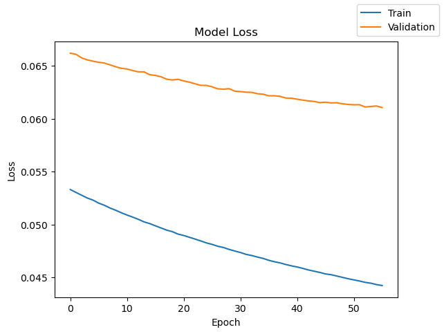

```python
plot(history,'loss')
```

```python
model_1_train_perf = model_performance_classification(model_1,X_train,y_train)
model_1_train_perf
```

```
500/500 ━━━━━━━━━━━━━━━━━━━━ 0s 155us/step
```

|  | Accuracy | Recall | Precision | F1 Score |
| --- | --- | --- | --- | --- |
| 0 | 0.9915 | 0.931903 | 0.985853 | 0.957088 |

```python
model_1_val_perf = model_performance_classification(model_1,X_val,y_val)
model_1_val_perf
```

```
125/125 ━━━━━━━━━━━━━━━━━━━━ 0s 198us/step
```

|  | Accuracy | Recall | Precision | F1 Score |
| --- | --- | --- | --- | --- |
| 0 | 0.9895 | 0.922365 | 0.975123 | 0.946991 |

```python
y_train_pred_1 = model_1.predict(X_train)
y_val_pred_1 = model_1.predict(X_val)
```

```
500/500 ━━━━━━━━━━━━━━━━━━━━ 0s 158us/step
125/125 ━━━━━━━━━━━━━━━━━━━━ 0s 158us/step
```

```python
print("Classification Report - Train data Model_1", end="\n\n")
cr_train_model_1 = classification_report(y_train,y_train_pred_1 > 0.5)
print(cr_train_model_1)
```

```
Classification Report - Train data Model_1

              precision    recall  f1-score   support

         0.0       0.99      1.00      1.00     15112
         1.0       0.98      0.86      0.92       888

    accuracy                           0.99     16000
   macro avg       0.99      0.93      0.96     16000
weighted avg       0.99      0.99      0.99     16000
```

```python
print("Classification Report - Validation data Model_1", end="\n\n")
cr_val_model_1 = classification_report(y_val,y_val_pred_1 > 0.5)
print(cr_val_model_1)
```

```
Classification Report - Validation data Model_1

              precision    recall  f1-score   support

         0.0       0.99      1.00      0.99      3778
         1.0       0.96      0.85      0.90       222

    accuracy                           0.99      4000
   macro avg       0.98      0.92      0.95      4000
weighted avg       0.99      0.99      0.99      4000
```

# Model 1 – Neural Network Performance Improvement

## Model Architecture

Model 1 was built as a more complex neural network than Model 0 by adding an additional hidden layer.

### Architecture

- Input features: 40 sensor variables
- Hidden Layer 1: 64 neurons with ReLU activation
- Hidden Layer 2: 32 neurons with ReLU activation
- Output Layer: 1 neuron with Sigmoid activation
- Total trainable parameters: 4,737

The additional hidden layer allows the model to learn more complex nonlinear relationships between turbine sensor readings and generator failure patterns.

## Model Loss Results

The loss plot shows that both training loss and validation loss decrease steadily across epochs.

### Key Observations

- Training loss decreases consistently over time.
- Validation loss also decreases, though it remains slightly higher than training loss.
- There is no major divergence between training and validation loss curves.

### Interpretation

This suggests that:

- the model is learning effectively,
- training is stable,
- the model is not severely overfitting,
- and the neural network is capturing meaningful patterns from the turbine sensor data.

## Validation Performance Results

The validation classification report shows the model’s performance on unseen validation data.

| Class | Precision | Recall | F1-Score | Support |
| --- | --- | --- | --- | --- |
| No Failure (0) | 0.99 | 1.00 | 0.99 | 3,778 |
| Failure (1) | 0.96 | 0.85 | 0.90 | 222 |

### Overall Validation Results

- Accuracy: 99%
- Macro Average Precision: 0.98
- Macro Average Recall: 0.92
- Macro Average F1-Score: 0.95
- Weighted Average F1-Score: 0.99

## What the Results Say

Model 1 performs very strongly on the validation data.

For the majority class, No Failure, the model performs almost perfectly:

- Precision is 0.99
- Recall is 1.00
- F1-score is 0.99

This means the model is highly effective at identifying normal turbine operations.

For the failure class, which is the most important class for this project:

- Precision is 0.96
- Recall is 0.85
- F1-score is 0.90

A failure precision of 0.96 means that when the model predicts a turbine failure, it is correct most of the time. This helps avoid unnecessary inspections and wasted maintenance resources.

A failure recall of 0.85 means the model correctly identifies about 85% of actual turbine failures. This is a strong result because failure cases are rare in the dataset.

The failure F1-score of 0.90 shows that the model has a strong balance between detecting failures and avoiding false alarms.

## Why This Is Important

The dataset is highly imbalanced, with only about 5.5% of observations representing actual failures. Because of this, accuracy alone can be misleading.

A model could achieve high accuracy by mostly predicting “No Failure,” but that would not solve the business problem. The main objective is to detect real failures early.

Model 1 is important because it does not only achieve high accuracy; it also performs well on the minority failure class.

The validation recall of 85% for failures shows that the model can identify most actual failures before breakdown occurs. This is critical because missed failures, or False Negatives, are the most expensive type of error in this project.

## Business Impact

Model 1 can support ReneWind’s predictive maintenance strategy by identifying turbines at risk of generator failure before complete breakdown.

### Key Business Benefits

- Helps detect most failure events early
- Reduces unexpected turbine breakdowns
- Supports proactive maintenance planning
- Lowers emergency repair and replacement costs
- Reduces operational downtime
- Improves turbine reliability and availability
- Helps maintenance teams focus on high-risk turbines

The high precision of 96% for failure predictions also means the model is not creating excessive false alarms. This helps reduce unnecessary inspections and improves trust in the model’s recommendations.

## Remaining Business Risk

Although Model 1 performs well, failure recall is still 85%, not 100%.

This means approximately 15% of actual failures may still be missed.

These missed failures remain a business risk because they can lead to:

- generator breakdown,
- expensive replacement costs,
- production losses,
- and unplanned downtime.

Further model tuning should focus on improving failure recall while maintaining reasonable precision.

## Overall Conclusion

Model 1 shows strong improvement potential and performs well on unseen validation data.

The model demonstrates:

- high overall accuracy,
- strong failure detection performance,
- high precision for failure predictions,
- stable training behavior,
- and limited signs of overfitting.

Overall, Model 1 is a strong candidate for predictive maintenance because it can help ReneWind detect generator failures earlier, reduce maintenance costs, and improve operational reliability.

## Model 2

To introduce Regularization in our model, let's set the dropout to 50% after adding the first hidden layer. This step will randomly drop 50% of the neurons before proceeding to the next layer, reducing overfitting.

```python
# clears the current Keras session, resetting all layers and models previously created, freeing up memory and resources.
tf.keras.backend.clear_session()
```

```python
#Initializing the neural network
from tensorflow.keras.layers import Dropout
model_2 = Sequential()
model_2.add(Dense(64,activation="relu",input_dim=X_train.shape[1]))  # Complete the code to define the number of neurons and activation function
model_2.add(Dropout(0.5)) # Complete the code to define the dropout rate
model_2.add(Dense(32,activation = "relu")) # Complete the code to define the number of neurons and activation function
model_2.add(Dense(16,activation = "relu")) # Complete the code to define the number of neurons and activation function
model_2.add(Dense(1,activation="sigmoid")) # Complete the code to define the number of neurons in the output layer
```

```python
model_2.summary()
```

```
Model: "sequential"
```

```
┏━━━━━━━━━━━━━━━━━━━━━━━━━━━━━━━━━┳━━━━━━━━━━━━━━━━━━━━━━━━┳━━━━━━━━━━━━━━━┓
┃ Layer (type)                    ┃ Output Shape           ┃       Param # ┃
┡━━━━━━━━━━━━━━━━━━━━━━━━━━━━━━━━━╇━━━━━━━━━━━━━━━━━━━━━━━━╇━━━━━━━━━━━━━━━┩
│ dense (Dense)                   │ (None, 64)             │         2,624 │
├─────────────────────────────────┼────────────────────────┼───────────────┤
│ dropout (Dropout)               │ (None, 64)             │             0 │
├─────────────────────────────────┼────────────────────────┼───────────────┤
│ dense_1 (Dense)                 │ (None, 32)             │         2,080 │
├─────────────────────────────────┼────────────────────────┼───────────────┤
│ dense_2 (Dense)                 │ (None, 16)             │           528 │
├─────────────────────────────────┼────────────────────────┼───────────────┤
│ dense_3 (Dense)                 │ (None, 1)              │            17 │
└─────────────────────────────────┴────────────────────────┴───────────────┘
```

```
 Total params: 5,249 (20.50 KB)
```

```
 Trainable params: 5,249 (20.50 KB)
```

```
 Non-trainable params: 0 (0.00 B)
```

```python
optimizer = tf.keras.optimizers.SGD()   # defining SGD as the optimizer to be used
# model_2.compile(loss='binary_crossentropy', optimizer=optimizer, metrics = ['accuracy']) ## Uncomment this line in case the metric of choice is Accuracy
# model_2.compile(loss='binary_crossentropy', optimizer=optimizer, metrics = ['Precision']) ## Uncomment this line in case the metric of choice is Precision
# model_2.compile(loss='binary_crossentropy', optimizer=optimizer, metrics = ['Recall']) ## Uncomment this line in case the metric of choice is Recall
# model_2.compile(loss='binary_crossentropy', optimizer=optimizer, metrics = ['f1_score']) ## Uncomment this line in case the metric of choice is F1 Score
```

```python
optimizer = tf.keras.optimizers.SGD()

model_2.compile(
    loss='binary_crossentropy',
    optimizer=optimizer,
    metrics=['Recall']
)

start = time.time()

history = model_2.fit(
    X_train,
    y_train,
    validation_data=(X_val,y_val),
    batch_size=batch_size,
    epochs=epochs
)

end=time.time()

print("Time taken in seconds ",end-start)
```

```
63/63 ━━━━━━━━━━━━━━━━━━━━ 0s 2ms/step - Recall: 0.1475 - loss: 0.2711 - val_Recall: 0.1081 - val_loss: 0.1834
63/63 ━━━━━━━━━━━━━━━━━━━━ 0s 663us/step - Recall: 0.1475 - loss: 0.2098 - val_Recall: 0.1982 - val_loss: 0.1641
63/63 ━━━━━━━━━━━━━━━━━━━━ 0s 598us/step - Recall: 0.1959 - loss: 0.1943 - val_Recall: 0.2523 - val_loss: 0.1527
63/63 ━━━━━━━━━━━━━━━━━━━━ 0s 701us/step - Recall: 0.2455 - loss: 0.1825 - val_Recall: 0.3063 - val_loss: 0.1442
63/63 ━━━━━━━━━━━━━━━━━━━━ 0s 638us/step - Recall: 0.2455 - loss: 0.1754 - val_Recall: 0.3468 - val_loss: 0.1380
63/63 ━━━━━━━━━━━━━━━━━━━━ 0s 698us/step - Recall: 0.2759 - loss: 0.1657 - val_Recall: 0.3829 - val_loss: 0.1329
63/63 ━━━━━━━━━━━━━━━━━━━━ 0s 672us/step - Recall: 0.3198 - loss: 0.1634 - val_Recall: 0.4099 - val_loss: 0.1287
63/63 ━━━━━━━━━━━━━━━━━━━━ 0s 660us/step - Recall: 0.3322 - loss: 0.1557 - val_Recall: 0.4234 - val_loss: 0.1248
63/63 ━━━━━━━━━━━━━━━━━━━━ 0s 648us/step - Recall: 0.3378 - loss: 0.1525 - val_Recall: 0.4550 - val_loss: 0.1216
63/63 ━━━━━━━━━━━━━━━━━━━━ 0s 658us/step - Recall: 0.3705 - loss: 0.1497 - val_Recall: 0.4640 - val_loss: 0.1186
63/63 ━━━━━━━━━━━━━━━━━━━━ 0s 643us/step - Recall: 0.3784 - loss: 0.1463 - val_Recall: 0.4730 - val_loss: 0.1161
63/63 ━━━━━━━━━━━━━━━━━━━━ 0s 715us/step - Recall: 0.4032 - loss: 0.1419 - val_Recall: 0.4910 - val_loss: 0.1137
63/63 ━━━━━━━━━━━━━━━━━━━━ 0s 668us/step - Recall: 0.4043 - loss: 0.1415 - val_Recall: 0.5000 - val_loss: 0.1115
63/63 ━━━━━━━━━━━━━━━━━━━━ 0s 708us/step - Recall: 0.4279 - loss: 0.1366 - val_Recall: 0.5315 - val_loss: 0.1093
63/63 ━━━━━━━━━━━━━━━━━━━━ 0s 741us/step - Recall: 0.4133 - loss: 0.1373 - val_Recall: 0.5586 - val_loss: 0.1072
63/63 ━━━━━━━━━━━━━━━━━━━━ 0s 817us/step - Recall: 0.4324 - loss: 0.1374 - val_Recall: 0.5766 - val_loss: 0.1056
63/63 ━━━━━━━━━━━━━━━━━━━━ 0s 612us/step - Recall: 0.4572 - loss: 0.1274 - val_Recall: 0.5901 - val_loss: 0.1040
63/63 ━━━━━━━━━━━━━━━━━━━━ 0s 624us/step - Recall: 0.4572 - loss: 0.1281 - val_Recall: 0.6036 - val_loss: 0.1023
63/63 ━━━━━━━━━━━━━━━━━━━━ 0s 655us/step - Recall: 0.4561 - loss: 0.1308 - val_Recall: 0.6081 - val_loss: 0.1008
63/63 ━━━━━━━━━━━━━━━━━━━━ 0s 629us/step - Recall: 0.4764 - loss: 0.1272 - val_Recall: 0.6126 - val_loss: 0.0993
63/63 ━━━━━━━━━━━━━━━━━━━━ 0s 645us/step - Recall: 0.4899 - loss: 0.1249 - val_Recall: 0.6171 - val_loss: 0.0979
63/63 ━━━━━━━━━━━━━━━━━━━━ 0s 787us/step - Recall: 0.4932 - loss: 0.1225 - val_Recall: 0.6396 - val_loss: 0.0965
63/63 ━━━━━━━━━━━━━━━━━━━━ 0s 770us/step - Recall: 0.5056 - loss: 0.1189 - val_Recall: 0.6261 - val_loss: 0.0952
63/63 ━━━━━━━━━━━━━━━━━━━━ 0s 702us/step - Recall: 0.5034 - loss: 0.1177 - val_Recall: 0.6441 - val_loss: 0.0941
63/63 ━━━━━━━━━━━━━━━━━━━━ 0s 692us/step - Recall: 0.5169 - loss: 0.1163 - val_Recall: 0.6486 - val_loss: 0.0929
63/63 ━━━━━━━━━━━━━━━━━━━━ 0s 627us/step - Recall: 0.5259 - loss: 0.1184 - val_Recall: 0.6577 - val_loss: 0.0919
63/63 ━━━━━━━━━━━━━━━━━━━━ 0s 674us/step - Recall: 0.5248 - loss: 0.1154 - val_Recall: 0.6622 - val_loss: 0.0907
63/63 ━━━━━━━━━━━━━━━━━━━━ 0s 669us/step - Recall: 0.5428 - loss: 0.1152 - val_Recall: 0.6622 - val_loss: 0.0897
63/63 ━━━━━━━━━━━━━━━━━━━━ 0s 629us/step - Recall: 0.5495 - loss: 0.1134 - val_Recall: 0.6622 - val_loss: 0.0888
63/63 ━━━━━━━━━━━━━━━━━━━━ 0s 691us/step - Recall: 0.5394 - loss: 0.1115 - val_Recall: 0.6757 - val_loss: 0.0878
63/63 ━━━━━━━━━━━━━━━━━━━━ 0s 660us/step - Recall: 0.5552 - loss: 0.1127 - val_Recall: 0.6757 - val_loss: 0.0868
63/63 ━━━━━━━━━━━━━━━━━━━━ 0s 652us/step - Recall: 0.5484 - loss: 0.1121 - val_Recall: 0.6892 - val_loss: 0.0860
63/63 ━━━━━━━━━━━━━━━━━━━━ 0s 685us/step - Recall: 0.5811 - loss: 0.1082 - val_Recall: 0.6847 - val_loss: 0.0854
63/63 ━━━━━━━━━━━━━━━━━━━━ 0s 668us/step - Recall: 0.5664 - loss: 0.1094 - val_Recall: 0.7027 - val_loss: 0.0845
63/63 ━━━━━━━━━━━━━━━━━━━━ 0s 655us/step - Recall: 0.5608 - loss: 0.1076 - val_Recall: 0.7027 - val_loss: 0.0838
63/63 ━━━━━━━━━━━━━━━━━━━━ 0s 582us/step - Recall: 0.5800 - loss: 0.1079 - val_Recall: 0.7027 - val_loss: 0.0832
63/63 ━━━━━━━━━━━━━━━━━━━━ 0s 607us/step - Recall: 0.5890 - loss: 0.1045 - val_Recall: 0.7117 - val_loss: 0.0824
63/63 ━━━━━━━━━━━━━━━━━━━━ 0s 647us/step - Recall: 0.6025 - loss: 0.1066 - val_Recall: 0.7117 - val_loss: 0.0817
```

[output cut: 19 more lines]

```python
start = time.time()
history = model_2.fit(X_train, y_train, validation_data=(X_val,y_val) , batch_size=batch_size, epochs=epochs)
end=time.time()
```

```
63/63 ━━━━━━━━━━━━━━━━━━━━ 0s 1ms/step - Recall: 0.6475 - loss: 0.0934 - val_Recall: 0.7568 - val_loss: 0.0726
63/63 ━━━━━━━━━━━━━━━━━━━━ 0s 680us/step - Recall: 0.6577 - loss: 0.0913 - val_Recall: 0.7613 - val_loss: 0.0722
63/63 ━━━━━━━━━━━━━━━━━━━━ 0s 647us/step - Recall: 0.6453 - loss: 0.0891 - val_Recall: 0.7613 - val_loss: 0.0719
63/63 ━━━━━━━━━━━━━━━━━━━━ 0s 716us/step - Recall: 0.6678 - loss: 0.0882 - val_Recall: 0.7568 - val_loss: 0.0716
63/63 ━━━━━━━━━━━━━━━━━━━━ 0s 731us/step - Recall: 0.6532 - loss: 0.0908 - val_Recall: 0.7613 - val_loss: 0.0714
63/63 ━━━━━━━━━━━━━━━━━━━━ 0s 659us/step - Recall: 0.6712 - loss: 0.0880 - val_Recall: 0.7613 - val_loss: 0.0710
63/63 ━━━━━━━━━━━━━━━━━━━━ 0s 683us/step - Recall: 0.6498 - loss: 0.0923 - val_Recall: 0.7613 - val_loss: 0.0706
63/63 ━━━━━━━━━━━━━━━━━━━━ 0s 638us/step - Recall: 0.6622 - loss: 0.0873 - val_Recall: 0.7658 - val_loss: 0.0704
63/63 ━━━━━━━━━━━━━━━━━━━━ 0s 650us/step - Recall: 0.6723 - loss: 0.0898 - val_Recall: 0.7613 - val_loss: 0.0700
63/63 ━━━━━━━━━━━━━━━━━━━━ 0s 645us/step - Recall: 0.6644 - loss: 0.0871 - val_Recall: 0.7658 - val_loss: 0.0698
63/63 ━━━━━━━━━━━━━━━━━━━━ 0s 701us/step - Recall: 0.6655 - loss: 0.0895 - val_Recall: 0.7658 - val_loss: 0.0696
63/63 ━━━━━━━━━━━━━━━━━━━━ 0s 668us/step - Recall: 0.6565 - loss: 0.0913 - val_Recall: 0.7658 - val_loss: 0.0693
63/63 ━━━━━━━━━━━━━━━━━━━━ 0s 711us/step - Recall: 0.6791 - loss: 0.0867 - val_Recall: 0.7613 - val_loss: 0.0691
63/63 ━━━━━━━━━━━━━━━━━━━━ 0s 670us/step - Recall: 0.6779 - loss: 0.0847 - val_Recall: 0.7613 - val_loss: 0.0688
63/63 ━━━━━━━━━━━━━━━━━━━━ 0s 622us/step - Recall: 0.6655 - loss: 0.0889 - val_Recall: 0.7793 - val_loss: 0.0686
63/63 ━━━━━━━━━━━━━━━━━━━━ 0s 717us/step - Recall: 0.6802 - loss: 0.0862 - val_Recall: 0.7748 - val_loss: 0.0684
63/63 ━━━━━━━━━━━━━━━━━━━━ 0s 660us/step - Recall: 0.6791 - loss: 0.0869 - val_Recall: 0.7793 - val_loss: 0.0682
63/63 ━━━━━━━━━━━━━━━━━━━━ 0s 766us/step - Recall: 0.6824 - loss: 0.0858 - val_Recall: 0.7748 - val_loss: 0.0680
63/63 ━━━━━━━━━━━━━━━━━━━━ 0s 679us/step - Recall: 0.6734 - loss: 0.0852 - val_Recall: 0.7838 - val_loss: 0.0678
63/63 ━━━━━━━━━━━━━━━━━━━━ 0s 688us/step - Recall: 0.6734 - loss: 0.0856 - val_Recall: 0.7838 - val_loss: 0.0676
63/63 ━━━━━━━━━━━━━━━━━━━━ 0s 705us/step - Recall: 0.6937 - loss: 0.0836 - val_Recall: 0.7793 - val_loss: 0.0675
63/63 ━━━━━━━━━━━━━━━━━━━━ 0s 698us/step - Recall: 0.6779 - loss: 0.0857 - val_Recall: 0.7793 - val_loss: 0.0672
63/63 ━━━━━━━━━━━━━━━━━━━━ 0s 648us/step - Recall: 0.6824 - loss: 0.0836 - val_Recall: 0.7793 - val_loss: 0.0671
63/63 ━━━━━━━━━━━━━━━━━━━━ 0s 660us/step - Recall: 0.7072 - loss: 0.0845 - val_Recall: 0.7748 - val_loss: 0.0670
63/63 ━━━━━━━━━━━━━━━━━━━━ 0s 671us/step - Recall: 0.6802 - loss: 0.0808 - val_Recall: 0.7793 - val_loss: 0.0667
63/63 ━━━━━━━━━━━━━━━━━━━━ 0s 684us/step - Recall: 0.6892 - loss: 0.0828 - val_Recall: 0.7838 - val_loss: 0.0666
63/63 ━━━━━━━━━━━━━━━━━━━━ 0s 621us/step - Recall: 0.6881 - loss: 0.0843 - val_Recall: 0.7838 - val_loss: 0.0664
63/63 ━━━━━━━━━━━━━━━━━━━━ 0s 682us/step - Recall: 0.7005 - loss: 0.0839 - val_Recall: 0.7973 - val_loss: 0.0663
63/63 ━━━━━━━━━━━━━━━━━━━━ 0s 638us/step - Recall: 0.7005 - loss: 0.0825 - val_Recall: 0.7973 - val_loss: 0.0661
63/63 ━━━━━━━━━━━━━━━━━━━━ 0s 627us/step - Recall: 0.7050 - loss: 0.0831 - val_Recall: 0.7883 - val_loss: 0.0659
63/63 ━━━━━━━━━━━━━━━━━━━━ 0s 710us/step - Recall: 0.6836 - loss: 0.0823 - val_Recall: 0.7928 - val_loss: 0.0658
63/63 ━━━━━━━━━━━━━━━━━━━━ 0s 696us/step - Recall: 0.6847 - loss: 0.0814 - val_Recall: 0.7973 - val_loss: 0.0656
63/63 ━━━━━━━━━━━━━━━━━━━━ 0s 709us/step - Recall: 0.6926 - loss: 0.0808 - val_Recall: 0.7928 - val_loss: 0.0655
63/63 ━━━━━━━━━━━━━━━━━━━━ 0s 637us/step - Recall: 0.7016 - loss: 0.0796 - val_Recall: 0.7928 - val_loss: 0.0655
63/63 ━━━━━━━━━━━━━━━━━━━━ 0s 635us/step - Recall: 0.6881 - loss: 0.0813 - val_Recall: 0.8018 - val_loss: 0.0654
63/63 ━━━━━━━━━━━━━━━━━━━━ 0s 634us/step - Recall: 0.7027 - loss: 0.0807 - val_Recall: 0.7928 - val_loss: 0.0652
63/63 ━━━━━━━━━━━━━━━━━━━━ 0s 655us/step - Recall: 0.6768 - loss: 0.0819 - val_Recall: 0.8018 - val_loss: 0.0651
```

[output cut: 19 more lines]

```python
print("Time taken in seconds ",end-start)
```

```
Time taken in seconds  2.7847299575805664
```

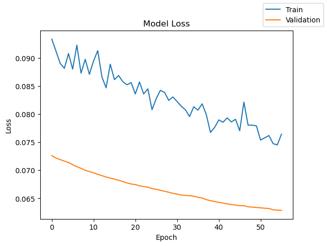

```python
plot(history,'loss')
```

Lets check the model performance of model_2 on training and validation data respectively.

```python
model_2_train_perf = model_performance_classification(model_2,X_train,y_train)
model_2_train_perf
```

```
500/500 ━━━━━━━━━━━━━━━━━━━━ 0s 149us/step
```

|  | Accuracy | Recall | Precision | F1 Score |
| --- | --- | --- | --- | --- |
| 0 | 0.987938 | 0.902458 | 0.980119 | 0.937438 |

```python
model_2_val_perf = model_performance_classification(model_2,X_val,y_val)
model_2_val_perf
```

```
125/125 ━━━━━━━━━━━━━━━━━━━━ 0s 240us/step
```

|  | Accuracy | Recall | Precision | F1 Score |
| --- | --- | --- | --- | --- |
| 0 | 0.9875 | 0.906467 | 0.970935 | 0.936026 |

```python
y_train_pred_2 = model_2.predict(X_train)
y_val_pred_2 = model_2.predict(X_val)
```

```
500/500 ━━━━━━━━━━━━━━━━━━━━ 0s 154us/step
125/125 ━━━━━━━━━━━━━━━━━━━━ 0s 156us/step
```

Lets check the classification report of model_2 on training and validation data respectively.

```python
print("Classification Report - Train data Model_2", end="\n\n")
cr_train_model_2 = classification_report(y_train,y_train_pred_2 > 0.5)
print(cr_train_model_2)
```

```
Classification Report - Train data Model_2

              precision    recall  f1-score   support

         0.0       0.99      1.00      0.99     15112
         1.0       0.97      0.81      0.88       888

    accuracy                           0.99     16000
   macro avg       0.98      0.90      0.94     16000
weighted avg       0.99      0.99      0.99     16000
```

```python
print("Classification Report - Validation data Model_2", end="\n\n")
cr_val_model_2 = classification_report(y_val , y_val_pred_2 > 0.5)
print(cr_val_model_2)
```

```
Classification Report - Validation data Model_2

              precision    recall  f1-score   support

         0.0       0.99      1.00      0.99      3778
         1.0       0.95      0.82      0.88       222

    accuracy                           0.99      4000
   macro avg       0.97      0.91      0.94      4000
weighted avg       0.99      0.99      0.99      4000
```

# Model 2 – Neural Network with Dropout Regularization

## Model Architecture

Model 2 was created to improve generalization and reduce overfitting by adding **Dropout regularization** after the first hidden layer.

### Architecture

- Input features: 40 sensor variables
- Hidden Layer 1: 64 neurons with ReLU activation
- Dropout Layer: 50% dropout
- Hidden Layer 2: 32 neurons with ReLU activation
- Hidden Layer 3: 16 neurons with ReLU activation
- Output Layer: 1 neuron with Sigmoid activation
- Total trainable parameters: 5,249

The purpose of adding dropout is to randomly deactivate 50% of neurons during training. This forces the model to learn more general patterns instead of relying too heavily on specific neurons.

## Model Loss Results

The loss plot shows that training loss is noisier than validation loss.

### Key Observations

- Training loss decreases overall but fluctuates across epochs.
- Validation loss decreases steadily and smoothly.
- Validation loss is lower than training loss, which can happen when dropout is active during training but not during validation.
- There is no major increase in validation loss, so severe overfitting is not observed.

### Interpretation

The model is learning useful patterns from the sensor data. The fluctuating training loss is expected because dropout randomly removes neurons during training, making the learning process less smooth. The steady validation loss suggests that dropout helped the model generalize to unseen data.

## Model 2 Performance Results

### Training Dataset Results

| Metric | No Failure (0) | Failure (1) |
| --- | --- | --- |
| Precision | 0.99 | 0.97 |
| Recall | 1.00 | 0.81 |
| F1-Score | 0.99 | 0.88 |

### Overall Training Performance

- Accuracy: 99%
- Macro Average Precision: 0.98
- Macro Average Recall: 0.90
- Macro Average F1-Score: 0.94
- Weighted Average F1-Score: 0.99

## Validation Dataset Results

| Metric | No Failure (0) | Failure (1) |
| --- | --- | --- |
| Precision | 0.99 | 0.95 |
| Recall | 1.00 | 0.82 |
| F1-Score | 0.99 | 0.88 |

### Overall Validation Performance

- Accuracy: 99%
- Macro Average Precision: 0.97
- Macro Average Recall: 0.91
- Macro Average F1-Score: 0.94
- Weighted Average F1-Score: 0.99

# What These Results Say

Model 2 performs very well overall, but its failure detection performance is slightly weaker than Model 1.

For the **No Failure** class:

- Recall is 1.00 on both training and validation data.
- This means the model is extremely good at identifying normal turbine operations.

For the **Failure** class:

- Training Recall is 0.81.
- Validation Recall is 0.82.
- This means the model correctly identifies about 82% of actual turbine failures on validation data.

For failure predictions:

- Validation Precision is 0.95.
- This means when the model predicts a failure, it is correct 95% of the time.

The Failure F1-Score is 0.88 on validation data, which shows a strong but slightly lower balance between Precision and Recall compared to Model 1.

# Why This Is Important

## 1. Dropout Reduced Overfitting Risk

Dropout is designed to reduce overfitting by preventing the model from relying too heavily on specific neurons.

The loss curve suggests that:

- the model continues learning,
- validation loss decreases steadily,
- and there is no severe overfitting.

This is useful because predictive maintenance models need to perform well on future unseen turbine data, not just the training data.

## 2. Failure Detection Remains Strong but Lower Than Model 1

The validation Recall for the failure class is 0.82.

This means:

- the model detects most failures,
- but misses about 18% of actual failures.

Because missed failures are the most expensive error in this project, this is an important limitation.

## 3. High Precision Reduces False Alarms

The validation Precision for the failure class is 0.95.

This means:

- most predicted failures are true failures,
- and the model does not create too many unnecessary maintenance alerts.

This is valuable because excessive false alarms can waste maintenance resources and reduce trust in the model.

## 4. Accuracy Alone Is Not Enough

The model has 99% accuracy, but the dataset is highly imbalanced.

Since only about 5.5% of observations are failures, a high accuracy score does not fully explain how well the model identifies failures.

Recall and F1-score are more important for judging model usefulness in this business problem.

# Business Impact

Model 2 can support predictive maintenance by identifying most generator failures before breakdown occurs.

### Positive Business Impact

- Helps detect at-risk turbines early.
- Reduces unexpected generator breakdowns.
- Supports proactive maintenance scheduling.
- Helps reduce emergency repair and replacement costs.
- Maintains high precision, limiting unnecessary inspections.

### Remaining Business Risk

Although Model 2 performs well, it misses about 18% of actual failures on validation data.

These missed failures are business-critical because they can lead to:

- expensive generator replacement,
- operational downtime,
- lost energy production,
- and higher maintenance costs.

# Comparison to Model 1

Compared with Model 1:

| Metric | Model 1 Validation | Model 2 Validation |
| --- | --- | --- |
| Accuracy | 99% | 99% |
| Failure Precision | 0.96 | 0.95 |
| Failure Recall | 0.85 | 0.82 |
| Failure F1-Score | 0.90 | 0.88 |

Model 2 has good performance, but Model 1 performs slightly better on the failure class.

This suggests that adding dropout improved regularization but may have slightly reduced the model’s ability to detect failures.

# Overall Conclusion

Model 2 is a strong regularized neural network model with stable validation performance and limited overfitting.

However, compared with Model 1, it has slightly lower failure Recall and F1-score.

Since the main business objective is to minimize missed failures, Model 2 may not be the best model so far, but it is still useful because it demonstrates how dropout affects model performance and generalization.

## Model 3

As we have are dealing with an imbalance in class distribution, we should also be using class weights to allow the model to give proportionally more importance to the minority class.

```python
# Calculate class weights for imbalanced dataset
cw = (y_train.shape[0]) / np.bincount(y_train.astype(int)) # Convert y_train to integers

# Create a dictionary mapping class indices to their respective class weights
cw_dict = {}
for i in range(cw.shape[0]):
    cw_dict[i] = cw[i]

cw_dict
```

```
{0: np.float64(1.0587612493382743), 1: np.float64(18.01801801801802)}
```

```
The history saving thread hit an unexpected error (OperationalError('attempt to write a readonly database')).History will not be written to the database.
```

```python
# clears the current Keras session, resetting all layers and models previously created, freeing up memory and resources.
tf.keras.backend.clear_session()
```

```python
model_3 = Sequential()
model_3.add(Dense(64,activation="relu",input_dim=X_train.shape[1])) # Complete the code to define the number of neurons and activation function
model_3.add(Dropout(0.5)) # Complete the code to define the dropout rate
model_3.add(Dense(32,activation="relu")) # Complete the code to define the number of neurons and activation function
model_3.add(Dense(16, activation = "relu")) # Complete the code to define the number of neurons and activation function
model_3.add(Dense(1,activation="sigmoid")) # Complete the code to define the number of neurons in the output layer
```

```python
model_3.summary()
```

```
Model: "sequential"
```

```
┏━━━━━━━━━━━━━━━━━━━━━━━━━━━━━━━━━┳━━━━━━━━━━━━━━━━━━━━━━━━┳━━━━━━━━━━━━━━━┓
┃ Layer (type)                    ┃ Output Shape           ┃       Param # ┃
┡━━━━━━━━━━━━━━━━━━━━━━━━━━━━━━━━━╇━━━━━━━━━━━━━━━━━━━━━━━━╇━━━━━━━━━━━━━━━┩
│ dense (Dense)                   │ (None, 64)             │         2,624 │
├─────────────────────────────────┼────────────────────────┼───────────────┤
│ dropout (Dropout)               │ (None, 64)             │             0 │
├─────────────────────────────────┼────────────────────────┼───────────────┤
│ dense_1 (Dense)                 │ (None, 32)             │         2,080 │
├─────────────────────────────────┼────────────────────────┼───────────────┤
│ dense_2 (Dense)                 │ (None, 16)             │           528 │
├─────────────────────────────────┼────────────────────────┼───────────────┤
│ dense_3 (Dense)                 │ (None, 1)              │            17 │
└─────────────────────────────────┴────────────────────────┴───────────────┘
```

```
 Total params: 5,249 (20.50 KB)
```

```
 Trainable params: 5,249 (20.50 KB)
```

```
 Non-trainable params: 0 (0.00 B)
```

```python
optimizer = tf.keras.optimizers.SGD()   # defining SGD as the optimizer to be used
# model_3.compile(loss='binary_crossentropy', optimizer=optimizer, metrics = ['accuracy']) ## Uncomment this line in case the metric of choice is Accuracy
# model_3.compile(loss='binary_crossentropy', optimizer=optimizer, metrics = ['Precision']) ## Uncomment this line in case the metric of choice is Precision
# model_3.compile(loss='binary_crossentropy', optimizer=optimizer, metrics = ['Recall']) ## Uncomment this line in case the metric of choice is Recall
# model_3.compile(loss='binary_crossentropy', optimizer=optimizer, metrics = ['f1_score']) ## Uncomment this line in case the metric of choice is F1 Score
```

```python
optimizer = tf.keras.optimizers.SGD()

model_3.compile(
    loss="binary_crossentropy",
    optimizer=optimizer,
    metrics=["Recall"]
)
```

```python
start = time.time()
history = model_3.fit(X_train, y_train, validation_data=(X_val,y_val) , batch_size=batch_size, epochs=epochs,class_weight=cw_dict)
end=time.time()
```

```
63/63 ━━━━━━━━━━━━━━━━━━━━ 0s 2ms/step - Recall: 0.6014 - loss: 1.2761 - val_Recall: 0.9144 - val_loss: 0.4974
63/63 ━━━━━━━━━━━━━━━━━━━━ 0s 663us/step - Recall: 0.8322 - loss: 0.9570 - val_Recall: 0.8739 - val_loss: 0.3476
63/63 ━━━━━━━━━━━━━━━━━━━━ 0s 615us/step - Recall: 0.8536 - loss: 0.8840 - val_Recall: 0.8874 - val_loss: 0.3413
63/63 ━━━━━━━━━━━━━━━━━━━━ 0s 645us/step - Recall: 0.8502 - loss: 0.8033 - val_Recall: 0.8784 - val_loss: 0.2886
63/63 ━━━━━━━━━━━━━━━━━━━━ 0s 642us/step - Recall: 0.8525 - loss: 0.7598 - val_Recall: 0.8694 - val_loss: 0.2756
63/63 ━━━━━━━━━━━━━━━━━━━━ 0s 631us/step - Recall: 0.8547 - loss: 0.7162 - val_Recall: 0.8649 - val_loss: 0.2756
63/63 ━━━━━━━━━━━━━━━━━━━━ 0s 568us/step - Recall: 0.8536 - loss: 0.6954 - val_Recall: 0.8784 - val_loss: 0.2989
63/63 ━━━━━━━━━━━━━━━━━━━━ 0s 636us/step - Recall: 0.8626 - loss: 0.6543 - val_Recall: 0.8784 - val_loss: 0.3347
63/63 ━━━━━━━━━━━━━━━━━━━━ 0s 612us/step - Recall: 0.8637 - loss: 0.6434 - val_Recall: 0.8649 - val_loss: 0.2055
63/63 ━━━━━━━━━━━━━━━━━━━━ 0s 619us/step - Recall: 0.8525 - loss: 0.6471 - val_Recall: 0.8694 - val_loss: 0.2287
63/63 ━━━━━━━━━━━━━━━━━━━━ 0s 620us/step - Recall: 0.8649 - loss: 0.6087 - val_Recall: 0.8694 - val_loss: 0.1969
63/63 ━━━━━━━━━━━━━━━━━━━━ 0s 647us/step - Recall: 0.8705 - loss: 0.5840 - val_Recall: 0.8874 - val_loss: 0.2209
63/63 ━━━━━━━━━━━━━━━━━━━━ 0s 576us/step - Recall: 0.8795 - loss: 0.5752 - val_Recall: 0.8874 - val_loss: 0.2307
63/63 ━━━━━━━━━━━━━━━━━━━━ 0s 616us/step - Recall: 0.8784 - loss: 0.5551 - val_Recall: 0.8784 - val_loss: 0.2501
63/63 ━━━━━━━━━━━━━━━━━━━━ 0s 582us/step - Recall: 0.8716 - loss: 0.5847 - val_Recall: 0.8829 - val_loss: 0.2261
63/63 ━━━━━━━━━━━━━━━━━━━━ 0s 607us/step - Recall: 0.8682 - loss: 0.5445 - val_Recall: 0.8874 - val_loss: 0.2523
63/63 ━━━━━━━━━━━━━━━━━━━━ 0s 579us/step - Recall: 0.8795 - loss: 0.5236 - val_Recall: 0.8784 - val_loss: 0.2058
63/63 ━━━━━━━━━━━━━━━━━━━━ 0s 632us/step - Recall: 0.8795 - loss: 0.5478 - val_Recall: 0.8874 - val_loss: 0.2559
63/63 ━━━━━━━━━━━━━━━━━━━━ 0s 660us/step - Recall: 0.8727 - loss: 0.5398 - val_Recall: 0.8829 - val_loss: 0.2290
63/63 ━━━━━━━━━━━━━━━━━━━━ 0s 689us/step - Recall: 0.8761 - loss: 0.5307 - val_Recall: 0.8784 - val_loss: 0.2512
63/63 ━━━━━━━━━━━━━━━━━━━━ 0s 627us/step - Recall: 0.8840 - loss: 0.5033 - val_Recall: 0.8829 - val_loss: 0.2531
63/63 ━━━━━━━━━━━━━━━━━━━━ 0s 634us/step - Recall: 0.8739 - loss: 0.5087 - val_Recall: 0.8829 - val_loss: 0.2325
63/63 ━━━━━━━━━━━━━━━━━━━━ 0s 595us/step - Recall: 0.8795 - loss: 0.5012 - val_Recall: 0.8874 - val_loss: 0.2048
63/63 ━━━━━━━━━━━━━━━━━━━━ 0s 650us/step - Recall: 0.8896 - loss: 0.4780 - val_Recall: 0.8829 - val_loss: 0.2218
63/63 ━━━━━━━━━━━━━━━━━━━━ 0s 607us/step - Recall: 0.8795 - loss: 0.4887 - val_Recall: 0.8739 - val_loss: 0.1868
63/63 ━━━━━━━━━━━━━━━━━━━━ 0s 569us/step - Recall: 0.8851 - loss: 0.4861 - val_Recall: 0.8874 - val_loss: 0.2247
63/63 ━━━━━━━━━━━━━━━━━━━━ 0s 623us/step - Recall: 0.8795 - loss: 0.4814 - val_Recall: 0.8784 - val_loss: 0.1935
63/63 ━━━━━━━━━━━━━━━━━━━━ 0s 678us/step - Recall: 0.8739 - loss: 0.4870 - val_Recall: 0.8874 - val_loss: 0.1940
63/63 ━━━━━━━━━━━━━━━━━━━━ 0s 691us/step - Recall: 0.8896 - loss: 0.4701 - val_Recall: 0.8784 - val_loss: 0.1941
63/63 ━━━━━━━━━━━━━━━━━━━━ 0s 753us/step - Recall: 0.8806 - loss: 0.4666 - val_Recall: 0.8829 - val_loss: 0.1665
63/63 ━━━━━━━━━━━━━━━━━━━━ 0s 709us/step - Recall: 0.8863 - loss: 0.4604 - val_Recall: 0.8829 - val_loss: 0.1937
63/63 ━━━━━━━━━━━━━━━━━━━━ 0s 700us/step - Recall: 0.8919 - loss: 0.4497 - val_Recall: 0.8829 - val_loss: 0.1693
63/63 ━━━━━━━━━━━━━━━━━━━━ 0s 611us/step - Recall: 0.8773 - loss: 0.4728 - val_Recall: 0.8829 - val_loss: 0.1944
63/63 ━━━━━━━━━━━━━━━━━━━━ 0s 615us/step - Recall: 0.8953 - loss: 0.4458 - val_Recall: 0.8829 - val_loss: 0.1894
63/63 ━━━━━━━━━━━━━━━━━━━━ 0s 707us/step - Recall: 0.8874 - loss: 0.4560 - val_Recall: 0.8829 - val_loss: 0.1642
63/63 ━━━━━━━━━━━━━━━━━━━━ 0s 689us/step - Recall: 0.8874 - loss: 0.4489 - val_Recall: 0.8919 - val_loss: 0.1893
63/63 ━━━━━━━━━━━━━━━━━━━━ 0s 1ms/step - Recall: 0.8818 - loss: 0.4606 - val_Recall: 0.8919 - val_loss: 0.1737
```

[output cut: 19 more lines]

```python
print("Time taken in seconds ",end-start)
```

```
Time taken in seconds  2.9769158363342285
```

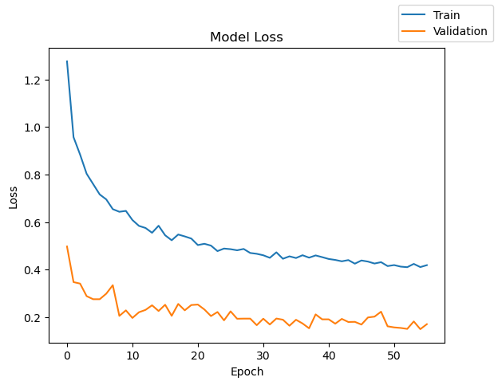

```python
plot(history,'loss')
```

Lets check the model performance of model_3 on training and validation data respectively.

```python
model_3_train_perf = model_performance_classification(model_3,X_train,y_train)
model_3_train_perf
```

```
500/500 ━━━━━━━━━━━━━━━━━━━━ 0s 150us/step
```

|  | Accuracy | Recall | Precision | F1 Score |
| --- | --- | --- | --- | --- |
| 0 | 0.983375 | 0.946151 | 0.905198 | 0.924538 |

```python
model_3_val_perf = model_performance_classification(model_3,X_val,y_val)
model_3_val_perf
```

```
125/125 ━━━━━━━━━━━━━━━━━━━━ 0s 249us/step
```

|  | Accuracy | Recall | Precision | F1 Score |
| --- | --- | --- | --- | --- |
| 0 | 0.984 | 0.940652 | 0.912777 | 0.926191 |

```python
y_train_pred_3 = model_3.predict(X_train)
y_val_pred_3 = model_3.predict(X_val)
```

```
500/500 ━━━━━━━━━━━━━━━━━━━━ 0s 161us/step
125/125 ━━━━━━━━━━━━━━━━━━━━ 0s 157us/step
```

Lets check the classification report of model_3 on training and validation data respectively.

```python
print("Classification Report - Train data Model_3", end="\n\n")
cr_train_model_3 = classification_report(y_train,y_train_pred_3 > 0.5)
print(cr_train_model_3)
```

```
Classification Report - Train data Model_3

              precision    recall  f1-score   support

         0.0       0.99      0.99      0.99     15112
         1.0       0.82      0.90      0.86       888

    accuracy                           0.98     16000
   macro avg       0.91      0.95      0.92     16000
weighted avg       0.98      0.98      0.98     16000
```

```python
print("Classification Report - Validation data Model_3", end="\n\n")
cr_val_model_3 = classification_report(y_val,y_val_pred_3 > 0.5)
print(cr_val_model_3)
```

```
Classification Report - Validation data Model_3

              precision    recall  f1-score   support

         0.0       0.99      0.99      0.99      3778
         1.0       0.83      0.89      0.86       222

    accuracy                           0.98      4000
   macro avg       0.91      0.94      0.93      4000
weighted avg       0.98      0.98      0.98      4000
```

# Model 3 – Neural Network with Dropout and Class Weights

## Model Architecture

Model 3 was built using the same architecture as Model 2, but class weights were added to handle the imbalance in the target variable.

### Architecture

- Input features: 40 sensor variables
- Hidden Layer 1: 64 neurons with ReLU activation
- Dropout Layer: 50% dropout
- Hidden Layer 2: 32 neurons with ReLU activation
- Hidden Layer 3: 16 neurons with ReLU activation
- Output Layer: 1 neuron with Sigmoid activation
- Total trainable parameters: 5,249

### Class Weights

Class weights were applied because the dataset is highly imbalanced.

- Class 0 / No Failure weight: 1.06
- Class 1 / Failure weight: 18.02

This means the model gives much more importance to failure cases during training.

## Model Loss Results

The loss plot shows that both training and validation loss decrease across epochs.

### Interpretation

This suggests that:

- the model is learning effectively,
- class weights are helping the model focus more on failure cases,
- dropout is supporting regularization,
- and the model does not show severe overfitting.

## Model 3 Performance Results

### Training Dataset Results

| Metric | No Failure (0) | Failure (1) |
| --- | --- | --- |
| Precision | 0.99 | 0.82 |
| Recall | 0.99 | 0.90 |
| F1-Score | 0.99 | 0.86 |

### Overall Training Performance

- Accuracy: 98%
- Macro Average Precision: 0.91
- Macro Average Recall: 0.95
- Macro Average F1-Score: 0.92
- Weighted Average F1-Score: 0.98

## Validation Dataset Results

| Metric | No Failure (0) | Failure (1) |
| --- | --- | --- |
| Precision | 0.99 | 0.83 |
| Recall | 0.99 | 0.89 |
| F1-Score | 0.99 | 0.86 |

### Overall Validation Performance

- Accuracy: 98%
- Macro Average Precision: 0.91
- Macro Average Recall: 0.94
- Macro Average F1-Score: 0.93
- Weighted Average F1-Score: 0.98

# What These Results Say

Model 3 shows strong improvement in detecting failure cases compared to the earlier dropout model.

For the **No Failure** class:

- Precision is 0.99.
- Recall is 0.99.
- F1-score is 0.99.

This means the model still performs very well in identifying normal turbine operations.

For the **Failure** class:

- Validation Precision is 0.83.
- Validation Recall is 0.89.
- Validation F1-score is 0.86.

A failure Recall of 0.89 means the model correctly identifies about 89% of actual turbine failures. This is a strong result because failures are rare and costly.

A failure Precision of 0.83 means that some predicted failures are false alarms, but most predicted failures are still correct.

The F1-score of 0.86 shows a reasonable balance between detecting failures and avoiding unnecessary alerts.

# Why This Is Important

## 1. Class Weights Improved Failure Detection

Model 3 uses class weights to give more importance to the minority class, which is turbine failure.

This matters because only about 5.5% of the observations represent failures. Without class weighting, the model may focus too heavily on predicting the majority class, No Failure.

By applying a higher weight to failure cases, the model becomes more sensitive to actual generator failures.

## 2. Higher Recall Reduces Missed Failures

The validation Recall for failures increased to 0.89.

This means Model 3 misses fewer actual failures than models with lower failure recall.

This is critical because missed failures, or False Negatives, are the most expensive type of error in this project.

## 3. Precision Decreased Compared to Earlier Models

The failure Precision is 0.83, which is lower than Model 1 and Model 2.

This means the model predicts more failures overall, which increases the number of false alarms.

However, this tradeoff may be acceptable because inspection costs are lower than replacement costs.

## 4. Accuracy Dropped Slightly but Business Value Improved

Model 3 has an accuracy of 98%, slightly lower than earlier models with 99% accuracy.

This drop is expected because the model is now more focused on identifying rare failure cases.

For this business problem, a small decrease in accuracy is acceptable if the model catches more actual failures.

# Business Impact

Model 3 is valuable because it prioritizes failure detection.

### Positive Business Impact

- Detects about 89% of actual failures on validation data.
- Reduces missed generator failures.
- Helps prevent expensive turbine breakdowns.
- Supports earlier maintenance intervention.
- Reduces replacement costs and operational downtime.
- Aligns well with the business goal of predictive maintenance.

### Operational Tradeoff

- Precision decreased to 83%.
- This means there may be more false alarms and inspections.
- However, inspection costs are lower than replacement costs, so this may be a reasonable tradeoff.

# Comparison to Previous Models

| Metric | Model 1 Validation | Model 2 Validation | Model 3 Validation |
| --- | --- | --- | --- |
| Accuracy | 99% | 99% | 98% |
| Failure Precision | 0.96 | 0.95 | 0.83 |
| Failure Recall | 0.85 | 0.82 | 0.89 |
| Failure F1-Score | 0.90 | 0.88 | 0.86 |

Model 3 improves failure Recall compared to Model 1 and Model 2, but Precision decreases.

This means Model 3 is better at catching failures, but it may generate more false alarms.

# Overall Conclusion

Model 3 is a strong model for the business objective because it improves failure detection.

Although accuracy and precision are slightly lower, the model has higher Recall for the failure class, which is the most important metric in this project.

Because missed failures are more expensive than extra inspections, Model 3 may be more valuable from a business perspective than models with higher precision but lower recall.

## Model 4

```python
# clears the current Keras session, resetting all layers and models previously created, freeing up memory and resources.
tf.keras.backend.clear_session()
```

```python
#Initializing the neural network
model_4 = Sequential()
model_4.add(Dense(64,activation="relu",input_dim=X_train.shape[1])) # Complete the code to define the number of neurons and activation function
model_4.add(Dense(32,activation="relu")) # Complete the code to define the number of neurons and activation function
model_4.add(Dense(1,activation="sigmoid")) # Complete the code to define the number of neurons in the output layer
```

```python
model_4.summary()
```

```
Model: "sequential"
```

```
┏━━━━━━━━━━━━━━━━━━━━━━━━━━━━━━━━━┳━━━━━━━━━━━━━━━━━━━━━━━━┳━━━━━━━━━━━━━━━┓
┃ Layer (type)                    ┃ Output Shape           ┃       Param # ┃
┡━━━━━━━━━━━━━━━━━━━━━━━━━━━━━━━━━╇━━━━━━━━━━━━━━━━━━━━━━━━╇━━━━━━━━━━━━━━━┩
│ dense (Dense)                   │ (None, 64)             │         2,624 │
├─────────────────────────────────┼────────────────────────┼───────────────┤
│ dense_1 (Dense)                 │ (None, 32)             │         2,080 │
├─────────────────────────────────┼────────────────────────┼───────────────┤
│ dense_2 (Dense)                 │ (None, 1)              │            33 │
└─────────────────────────────────┴────────────────────────┴───────────────┘
```

```
 Total params: 4,737 (18.50 KB)
```

```
 Trainable params: 4,737 (18.50 KB)
```

```
 Non-trainable params: 0 (0.00 B)
```

```python
optimizer = tf.keras.optimizers.Adam()    # defining Adam as the optimizer to be used
# model_4.compile(loss='binary_crossentropy', optimizer=optimizer, metrics = ['accuracy']) ## Uncomment this line in case the metric of choice is Accuracy
# model_4.compile(loss='binary_crossentropy', optimizer=optimizer, metrics = ['Precision']) ## Uncomment this line in case the metric of choice is Precision
# model_4.compile(loss='binary_crossentropy', optimizer=optimizer, metrics = ['Recall']) ## Uncomment this line in case the metric of choice is Recall
# model_4.compile(loss='binary_crossentropy', optimizer=optimizer, metrics = ['f1_score']) ## Uncomment this line in case the metric of choice is F1 Score
```

```python
optimizer = tf.keras.optimizers.SGD()

model_4.compile(
    loss="binary_crossentropy",
    optimizer=optimizer,
    metrics=["Recall"]
)
```

```python
start = time.time()
history = model_4.fit(X_train, y_train, validation_data=(X_val,y_val) , batch_size=batch_size, epochs=epochs)
end=time.time()
```

```
63/63 ━━━━━━━━━━━━━━━━━━━━ 0s 1ms/step - Recall: 0.0225 - loss: 0.2044 - val_Recall: 0.0901 - val_loss: 0.1749
63/63 ━━━━━━━━━━━━━━━━━━━━ 0s 529us/step - Recall: 0.1655 - loss: 0.1602 - val_Recall: 0.2297 - val_loss: 0.1464
63/63 ━━━━━━━━━━━━━━━━━━━━ 0s 520us/step - Recall: 0.3041 - loss: 0.1373 - val_Recall: 0.3378 - val_loss: 0.1301
63/63 ━━━━━━━━━━━━━━━━━━━━ 0s 559us/step - Recall: 0.3885 - loss: 0.1230 - val_Recall: 0.4685 - val_loss: 0.1194
63/63 ━━━━━━━━━━━━━━━━━━━━ 0s 534us/step - Recall: 0.4527 - loss: 0.1129 - val_Recall: 0.4955 - val_loss: 0.1111
63/63 ━━━━━━━━━━━━━━━━━━━━ 0s 514us/step - Recall: 0.5011 - loss: 0.1053 - val_Recall: 0.5676 - val_loss: 0.1050
63/63 ━━━━━━━━━━━━━━━━━━━━ 0s 523us/step - Recall: 0.5484 - loss: 0.0993 - val_Recall: 0.6036 - val_loss: 0.1000
63/63 ━━━━━━━━━━━━━━━━━━━━ 0s 523us/step - Recall: 0.5822 - loss: 0.0946 - val_Recall: 0.6261 - val_loss: 0.0960
63/63 ━━━━━━━━━━━━━━━━━━━━ 0s 537us/step - Recall: 0.6194 - loss: 0.0906 - val_Recall: 0.6306 - val_loss: 0.0925
63/63 ━━━━━━━━━━━━━━━━━━━━ 0s 562us/step - Recall: 0.6385 - loss: 0.0874 - val_Recall: 0.6577 - val_loss: 0.0897
63/63 ━━━━━━━━━━━━━━━━━━━━ 0s 557us/step - Recall: 0.6577 - loss: 0.0846 - val_Recall: 0.6892 - val_loss: 0.0876
63/63 ━━━━━━━━━━━━━━━━━━━━ 0s 591us/step - Recall: 0.6892 - loss: 0.0822 - val_Recall: 0.6937 - val_loss: 0.0851
63/63 ━━━━━━━━━━━━━━━━━━━━ 0s 557us/step - Recall: 0.6948 - loss: 0.0801 - val_Recall: 0.7027 - val_loss: 0.0833
63/63 ━━━━━━━━━━━━━━━━━━━━ 0s 534us/step - Recall: 0.7027 - loss: 0.0782 - val_Recall: 0.7297 - val_loss: 0.0817
63/63 ━━━━━━━━━━━━━━━━━━━━ 0s 568us/step - Recall: 0.7061 - loss: 0.0765 - val_Recall: 0.7342 - val_loss: 0.0802
63/63 ━━━━━━━━━━━━━━━━━━━━ 0s 572us/step - Recall: 0.7207 - loss: 0.0750 - val_Recall: 0.7432 - val_loss: 0.0789
63/63 ━━━━━━━━━━━━━━━━━━━━ 0s 636us/step - Recall: 0.7331 - loss: 0.0736 - val_Recall: 0.7477 - val_loss: 0.0776
63/63 ━━━━━━━━━━━━━━━━━━━━ 0s 652us/step - Recall: 0.7376 - loss: 0.0723 - val_Recall: 0.7568 - val_loss: 0.0766
63/63 ━━━━━━━━━━━━━━━━━━━━ 0s 638us/step - Recall: 0.7466 - loss: 0.0711 - val_Recall: 0.7658 - val_loss: 0.0759
63/63 ━━━━━━━━━━━━━━━━━━━━ 0s 595us/step - Recall: 0.7624 - loss: 0.0701 - val_Recall: 0.7658 - val_loss: 0.0748
63/63 ━━━━━━━━━━━━━━━━━━━━ 0s 599us/step - Recall: 0.7624 - loss: 0.0691 - val_Recall: 0.7703 - val_loss: 0.0738
63/63 ━━━━━━━━━━━━━━━━━━━━ 0s 620us/step - Recall: 0.7646 - loss: 0.0681 - val_Recall: 0.7703 - val_loss: 0.0730
63/63 ━━━━━━━━━━━━━━━━━━━━ 0s 647us/step - Recall: 0.7714 - loss: 0.0672 - val_Recall: 0.7703 - val_loss: 0.0723
63/63 ━━━━━━━━━━━━━━━━━━━━ 0s 588us/step - Recall: 0.7725 - loss: 0.0664 - val_Recall: 0.7703 - val_loss: 0.0717
63/63 ━━━━━━━━━━━━━━━━━━━━ 0s 647us/step - Recall: 0.7748 - loss: 0.0657 - val_Recall: 0.7748 - val_loss: 0.0710
63/63 ━━━━━━━━━━━━━━━━━━━━ 0s 589us/step - Recall: 0.7804 - loss: 0.0649 - val_Recall: 0.7793 - val_loss: 0.0704
63/63 ━━━━━━━━━━━━━━━━━━━━ 0s 559us/step - Recall: 0.7838 - loss: 0.0642 - val_Recall: 0.7838 - val_loss: 0.0698
63/63 ━━━━━━━━━━━━━━━━━━━━ 0s 552us/step - Recall: 0.7872 - loss: 0.0635 - val_Recall: 0.7883 - val_loss: 0.0693
63/63 ━━━━━━━━━━━━━━━━━━━━ 0s 553us/step - Recall: 0.7939 - loss: 0.0629 - val_Recall: 0.7838 - val_loss: 0.0687
63/63 ━━━━━━━━━━━━━━━━━━━━ 0s 602us/step - Recall: 0.7928 - loss: 0.0623 - val_Recall: 0.7838 - val_loss: 0.0683
63/63 ━━━━━━━━━━━━━━━━━━━━ 0s 556us/step - Recall: 0.7984 - loss: 0.0617 - val_Recall: 0.7838 - val_loss: 0.0678
63/63 ━━━━━━━━━━━━━━━━━━━━ 0s 536us/step - Recall: 0.7984 - loss: 0.0611 - val_Recall: 0.7838 - val_loss: 0.0674
63/63 ━━━━━━━━━━━━━━━━━━━━ 0s 517us/step - Recall: 0.8041 - loss: 0.0606 - val_Recall: 0.7928 - val_loss: 0.0670
63/63 ━━━━━━━━━━━━━━━━━━━━ 0s 535us/step - Recall: 0.8086 - loss: 0.0601 - val_Recall: 0.7928 - val_loss: 0.0666
63/63 ━━━━━━━━━━━━━━━━━━━━ 0s 547us/step - Recall: 0.8131 - loss: 0.0595 - val_Recall: 0.7883 - val_loss: 0.0662
63/63 ━━━━━━━━━━━━━━━━━━━━ 0s 554us/step - Recall: 0.8086 - loss: 0.0591 - val_Recall: 0.7883 - val_loss: 0.0659
63/63 ━━━━━━━━━━━━━━━━━━━━ 0s 570us/step - Recall: 0.8097 - loss: 0.0587 - val_Recall: 0.7928 - val_loss: 0.0656
```

[output cut: 19 more lines]

```python
print("Time taken in seconds ",end-start)
```

```
Time taken in seconds  2.5611839294433594
```

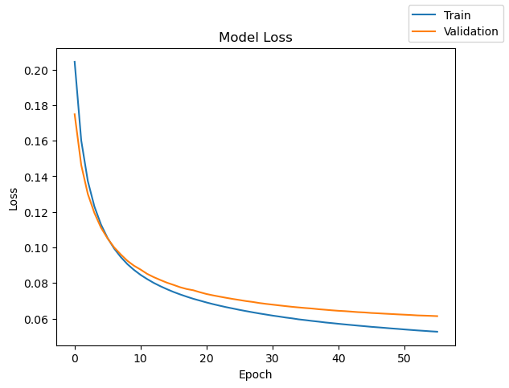

```python
plot(history,'loss')
```

Lets check the model performance ofr model_4 on training and validation data respectively

```python
model_4_train_perf = model_performance_classification(model_4,X_train,y_train)
model_4_train_perf
```

```
500/500 ━━━━━━━━━━━━━━━━━━━━ 0s 146us/step
```

|  | Accuracy | Recall | Precision | F1 Score |
| --- | --- | --- | --- | --- |
| 0 | 0.989563 | 0.914978 | 0.983822 | 0.946428 |

```python
model_4_val_perf = model_performance_classification(model_4,X_val,y_val)
model_4_val_perf
```

```
125/125 ━━━━━━━━━━━━━━━━━━━━ 0s 240us/step
```

|  | Accuracy | Recall | Precision | F1 Score |
| --- | --- | --- | --- | --- |
| 0 | 0.9885 | 0.906996 | 0.981184 | 0.940598 |

```python
y_train_pred_4 = model_4.predict(X_train)
y_val_pred_4 = model_4.predict(X_val)
```

```
500/500 ━━━━━━━━━━━━━━━━━━━━ 0s 154us/step
125/125 ━━━━━━━━━━━━━━━━━━━━ 0s 150us/step
```

Lets check the classification report of model_4 on raining and validation data respectively.

```python
print("Classification Report - Train data Model_4", end="\n\n")
cr_train_model_4 = classification_report(y_train,y_train_pred_4 > 0.5)
print(cr_train_model_4)
```

```
Classification Report - Train data Model_4

              precision    recall  f1-score   support

         0.0       0.99      1.00      0.99     15112
         1.0       0.98      0.83      0.90       888

    accuracy                           0.99     16000
   macro avg       0.98      0.91      0.95     16000
weighted avg       0.99      0.99      0.99     16000
```

```python
print("Classification Report - Validation data Model_4", end="\n\n")
cr_val_model_4 = classification_report(y_val,y_val_pred_4 > 0.5)
print(cr_val_model_4)
```

```
Classification Report - Validation data Model_4

              precision    recall  f1-score   support

         0.0       0.99      1.00      0.99      3778
         1.0       0.97      0.82      0.89       222

    accuracy                           0.99      4000
   macro avg       0.98      0.91      0.94      4000
weighted avg       0.99      0.99      0.99      4000
```